# False positives in multilevel models for longitudinal data

Do we need to control for the outcome’s t-1 score? Lagged and concurrent effects, prior-outcome control, person-mean centering, AR(1) residuals, and the RI-CLPM, by simulation

John Flournoy

2026-10-14

In 2018 I started a postdoc and was collaborating on decisions about how to model monthly data over the course of a year. The goal was to see if some variable measured the *previous* month ($x_{t-1}$) predicts the outcome *this* month ($y_{t}$). Having worked on several longitudinal datasets in graduate school, I had learned that it is crucial to control for the *previous* month’s level of the outcome variable, or else risk spurious effects driven by non-causal correlations between the constructs being measured. I wanted to see if the way collaborators were proposing to run these analyses was really problematic, and I wanted to explore any other ways to correct for these kinds of confounds. To do so, I simulated data where x and y move together over time but neither causes the other, and checked how often we conclude erroneously that $x_{t-1} \rightarrow y_{t}$. The short version: leave out last month’s y and you get a high false positive rate, and when people also differ in stable ways on these constructs, some fixes that work in some situations don’t fully work. None of these problems is new (see the references); this page puts them side by side for monthly data. Varying the design (near the end) adds that centering on observed person means brings a bias of its own when y is less stable than x and the two move together within a wave.

*Keywords: multilevel models, mixed-effects models, longitudinal data, intensive longitudinal data, monthly assessments, multiwave prospective design, within-person fluctuations, within-person and between-person effects, person-mean centering, lagged effects, concurrent effects, time-varying predictors, prior outcome, autoregressive models, cross-lagged panel model, RI-CLPM, Nickell bias, false positive rate, Type I error, stressful life events, anxiety and depression symptoms, adolescence, simulation.*

```r
# The keywords live in .zenodo.json; the page's meta tags (ar_stuff_head.html)
# must list the same ones, so the two can't drift apart.
page_keywords <- jsonlite::fromJSON('.zenodo.json')$keywords
head_keywords <- sub('.*<meta name="keywords" content="([^"]*)".*', '\\1',
                     paste(readLines('ar_stuff_head.html'), collapse = ' '))
if (!identical(strsplit(head_keywords, ', ')[[1]], page_keywords)) {
  stop('ar_stuff_head.html keywords differ from .zenodo.json; update the meta tag to match.')
}
```

```r
library(simsem)
library(nlme)
library(lmerTest)
library(lme4)
library(semPlot)
library(dplyr)
library(tidyr)
library(ggplot2)

N_seq = c(seq(30, 150, 40), seq(300, 1050, 150))

# Simulation results come from sim_riclpm.R (see "How the simulations work").
# LAGGED_RESULTS_DIR and LAGGED_EXPECTED_REPS exist only so a pilot run can be
# rendered without editing this file; the published page uses the defaults.
results_dir <- Sys.getenv("LAGGED_RESULTS_DIR", "riclpm_sims_r10000")
expected_reps <- as.integer(Sys.getenv("LAGGED_EXPECTED_REPS", "10000"))

# install.packages(c('simsem', 'nlme', 'lmerTest', 'lme4', 'semPlot', 'dplyr', 'tidyr', 'ggplot2'))
```

```r
if(is.na(expected_reps) || expected_reps < 1){
  stop('LAGGED_EXPECTED_REPS must be a positive integer; got "', Sys.getenv("LAGGED_EXPECTED_REPS"), '".')
}
if(!dir.exists(results_dir)){
  stop('Simulation results directory "', results_dir, '" does not exist. Run sim_riclpm.R ',
       '(Rscript sim_riclpm.R ', expected_reps, ' <cores>) or set LAGGED_RESULTS_DIR.')
}
summary_file <- file.path(results_dir, 'riclpm_sims_summary.RDS')
if(!file.exists(summary_file)){
  stop('Expected the simulation summary at ', summary_file, '; sim_riclpm.R writes it when every chunk is done.')
}
sim_sum <- as.data.frame(readRDS(summary_file))

needed_cols <- c('trait_var', 'spec', 'n', 'reps', 'failed', 'n_valid', 'reps_with_warnings',
                 'fp_rate', 'mc_se', 'mean_est', 'sd_est')
if(!all(needed_cols %in% names(sim_sum))){
  stop('Simulation summary is missing columns: ', paste(setdiff(needed_cols, names(sim_sum)), collapse = ', '))
}

spec_labels <- c(
  naive = 'y ~ x_lag (naive)',
  sea = 'centered x_lag + person mean + time (within/between)',
  no_wcen_ar = 'y ~ x_lag, AR(1)',
  no_wcen_ylag = 'y ~ y_lag + x_lag',
  wcen_ar = 'centered x_lag, AR(1)',
  wcen_ylag = 'centered y_lag + x_lag (nlme)',
  wcen_x_raw_ylag = 'raw y_lag + centered x_lag',
  wcen_ylag_l4 = 'centered y_lag + x_lag (lme4, Satterthwaite)',
  wcen_ylag_l4_wcenre = 'centered y_lag + x_lag (lme4, Satterthwaite, random slope)',
  riclpm = 'RI-CLPM')

# Every spec on all three generating models, except the RI-CLPM fit, which is
# not run on CLPM data (its trait variance would sit at the boundary of zero).
expected_cells <- rbind(
  expand.grid(trait_var = c(0, .5, 1), spec = setdiff(names(spec_labels), 'riclpm'), n = N_seq,
              stringsAsFactors = FALSE),
  expand.grid(trait_var = c(.5, 1), spec = 'riclpm', n = N_seq, stringsAsFactors = FALSE))
if(nrow(expected_cells) != 290) stop('Internal error: the expected design should have 290 cells, not ', nrow(expected_cells))

cell_key <- function(d) paste(d$trait_var, d$spec, d$n, sep = '/')
if(anyDuplicated(cell_key(sim_sum))){
  stop('Simulation summary has duplicated cells: ', paste(unique(cell_key(sim_sum)[duplicated(cell_key(sim_sum))]), collapse = ', '))
}
missing_cells <- setdiff(cell_key(expected_cells), cell_key(sim_sum))
extra_cells <- setdiff(cell_key(sim_sum), cell_key(expected_cells))
if(length(missing_cells) > 0 || length(extra_cells) > 0 || nrow(sim_sum) != nrow(expected_cells)){
  stop('Simulation summary has ', nrow(sim_sum), ' cells; expected ', nrow(expected_cells), '. Missing: ',
       paste(missing_cells, collapse = ', '), '. Unexpected: ', paste(extra_cells, collapse = ', '))
}
if(!identical(sort(unique(sim_sum$n)), sort(N_seq))){
  stop('Simulation summary sample sizes do not match N_seq.')
}
if(any(sim_sum$reps != expected_reps)){
  stop('Every simulation cell should have ', expected_reps, ' replications; these do not: ',
       paste(cell_key(sim_sum[sim_sum$reps != expected_reps, ]), collapse = ', '))
}
if(any(sim_sum$n_valid + sim_sum$failed != sim_sum$reps)){
  stop('Some simulation cells have replications that are neither valid nor recorded as failed: ',
       paste(cell_key(sim_sum[sim_sum$n_valid + sim_sum$failed != sim_sum$reps, ]), collapse = ', '))
}
if(anyNA(sim_sum[needed_cols])){
  stop('Simulation summary has missing values in: ', paste(needed_cols[sapply(sim_sum[needed_cols], anyNA)], collapse = ', '))
}
if(any(sim_sum$fp_rate < 0 | sim_sum$fp_rate > 1) || any(sim_sum$reps_with_warnings < 0 | sim_sum$reps_with_warnings > sim_sum$reps)){
  stop('Simulation summary has rates outside [0, 1] or warning counts outside [0, reps].')
}
if(any(sim_sum$n_valid < 2)){
  stop('Some simulation cells have fewer than 2 valid replications: ',
       paste(cell_key(sim_sum[sim_sum$n_valid < 2, ]), collapse = ', '))
}
trait_levels <- c('0 (CLPM)', '.5', '1')
trait_label <- function(tv){
  out <- c('0' = '0 (CLPM)', '0.5' = '.5', '1' = '1')[as.character(tv)]
  if(any(is.na(out))) stop('Unexpected trait variance: ', paste(tv[is.na(out)], collapse = ', '))
  unname(out)
}
trait_colors <- c('0 (CLPM)' = '#7a7a7a', '.5' = '#2a78d6', '1' = '#d4572a')
trait_shapes <- c('0 (CLPM)' = 16, '.5' = 17, '1' = 15)
fp_floor <- .01

# Leading-zero-free numbers, as in ".05".
f3 <- function(x, digits = 3) sub('^(-?)0\\.', '\\1.', formatC(round(x, digits) + 0, format = 'f', digits = digits))

sim_theme <- function(){
  theme_minimal(base_size = 12) +
    theme(legend.position = 'bottom',
          panel.grid.minor = element_blank(),
          axis.text.x = element_text(angle = 45, hjust = 1))
}
n_scale <- function() scale_x_sqrt(breaks = N_seq, name = 'Sample size (N, square-root scale)')
trait_scales <- function(){
  list(scale_color_manual(values = trait_colors, limits = trait_levels, drop = FALSE, name = 'Data-generating model\ntrait variance'),
       scale_shape_manual(values = trait_shapes, limits = trait_levels, drop = FALSE, name = 'Data-generating model\ntrait variance'))
}

# One plot pair per model specification, from the summary: the false-positive
# rate on a log scale (reference line at .05, bars from a Wilson interval with
# z = 2, about +/-2 Monte Carlo SE), and
# the average estimate (reference line at 0, bars at +/-2 SE of the mean).
plot_spec <- function(spec_name){
  d <- sim_sum[sim_sum$spec == spec_name, ]
  if(nrow(d) == 0) stop('No simulation results for spec "', spec_name, '".')
  d$trait <- factor(trait_label(d$trait_var), levels = trait_levels)
  d$fp_plot <- pmax(d$fp_rate, fp_floor)
  # Wilson interval with z = 2, which (unlike rate +/- 2 SE) doesn't collapse
  # to a point at rates of 0 or 1.
  z <- 2
  centre <- (d$fp_rate + z^2 / (2 * d$n_valid)) / (1 + z^2 / d$n_valid)
  half <- z * sqrt(d$fp_rate * (1 - d$fp_rate) / d$n_valid + z^2 / (4 * d$n_valid^2)) / (1 + z^2 / d$n_valid)
  d$fp_lo <- pmax(centre - half, fp_floor)
  d$fp_hi <- pmax(pmin(centre + half, 1), fp_floor)
  d$est_se <- d$sd_est / sqrt(d$n_valid)
  dodge <- position_dodge(width = .8)
  n_floored <- sum(d$fp_rate < fp_floor)
  floor_note <- if(n_floored > 0) sprintf('%d rate(s) below %s drawn at %s', n_floored, f3(fp_floor, 2), f3(fp_floor, 2)) else NULL

  fp_plot <- ggplot(d, aes(x = n, y = fp_plot, color = trait, shape = trait)) +
    geom_hline(yintercept = .05, color = 'gray30', linetype = 'dashed') +
    geom_linerange(aes(ymin = fp_lo, ymax = fp_hi), position = dodge) +
    geom_line(position = dodge, linewidth = .5) +
    geom_point(position = dodge, size = 2, show.legend = TRUE) +
    scale_y_log10(limits = c(fp_floor, 1), breaks = c(.01, .025, .05, .1, .25, .5, 1),
                  labels = c('.01', '.025', '.05', '.1', '.25', '.5', '1')) +
    n_scale() + trait_scales() +
    labs(y = 'Proportion with p < .05 (log scale)', title = 'False-positive rate', caption = floor_note) +
    sim_theme()

  est_plot <- ggplot(d, aes(x = n, y = mean_est, color = trait, shape = trait)) +
    geom_hline(yintercept = 0, color = 'gray30', linetype = 'dashed') +
    geom_linerange(aes(ymin = mean_est - 2 * est_se, ymax = mean_est + 2 * est_se), position = dodge) +
    geom_line(position = dodge, linewidth = .5) +
    geom_point(position = dodge, size = 2, show.legend = TRUE) +
    n_scale() + trait_scales() +
    labs(y = 'Average estimate of lagged x (true value 0)', title = 'Average estimate') +
    sim_theme()

  print(fp_plot)
  print(est_plot)
}

# Lookups for numbers quoted in the text; each stops if a cell is missing.
cells <- function(spec, tv, n = N_seq){
  d <- sim_sum[sim_sum$spec %in% spec & sim_sum$trait_var %in% tv & sim_sum$n %in% n, ]
  if(nrow(d) != length(spec) * length(tv) * length(n)){
    stop('Expected ', length(spec) * length(tv) * length(n), ' cells for ', paste(spec, collapse = '+'),
         ' at trait variance ', paste(tv, collapse = '/'), '; found ', nrow(d))
  }
  d
}
avg_est <- function(spec, tv) mean(cells(spec, tv)$mean_est)
rng <- function(x, digits = 3) paste0(f3(min(x), digits), ' to ', f3(max(x), digits))
max_abs <- function(x, digits = 3) f3(max(abs(x)), digits)
# Cells more than two Monte Carlo SEs from .05, using the SE a rate of .05
# would have (the SE at the observed rate is 0 when the rate is 0 or 1).
null_se <- function(d) sqrt(.05 * .95 / d$n_valid)
n_hot <- function(spec, tv){ d <- cells(spec, tv); sum(d$fp_rate - .05 > 2 * null_se(d)) }
n_off <- function(spec, tv){ d <- cells(spec, tv); sum(abs(d$fp_rate - .05) > 2 * null_se(d)) }
n_cells <- function(spec, tv) nrow(cells(spec, tv))
max_n <- max(N_seq)
```

```r
make_clpm_lavaan <- function(generate = T, generating_params = list(s = .7,cl = 0,r = 1,co = .5)){
  if(generate){
    b <- lapply(generating_params, paste0, '*')
  } else {
    b <- as.list(rep('', length(generating_params)))
    names(b) <- names(generating_params)
  }

  var_at_wave <- lapply(c('x', 'y'), paste0, 1:12)

  stabilityX <- paste(unlist(
    lapply(2:length(var_at_wave[[1]]),
           function(i){
             paste0(var_at_wave[[1]][i], ' ~ ', b$s, var_at_wave[[1]][i-1])
           })),
    collapse = '\n')

  stabilityY <- paste(unlist(
    lapply(2:length(var_at_wave[[1]]),
           function(i){
             paste0(var_at_wave[[2]][i], ' ~ ', b$s, var_at_wave[[2]][i-1])
           })),
    collapse = '\n')


  residuals <- paste(unlist(
    lapply(var_at_wave,
           function(thing){
             paste0(thing, ' ~~ ', b$r, thing)
           })),
    collapse = '\n')

  correlation <- paste(unlist(
    lapply(1:length(var_at_wave[[1]]),
           function(i){
             paste0(var_at_wave[[1]][i], ' ~~ ', b$co, var_at_wave[[2]][i])
           })),
    collapse = '\n')

  regressionsX <- paste(unlist(
    lapply(2:length(var_at_wave[[1]]),
           function(i){
             paste0(var_at_wave[[1]][i], ' ~ ', b$cl, var_at_wave[[2]][i-1])
           })),
    collapse = '\n')

  regressionsY <- paste(unlist(
    lapply(2:length(var_at_wave[[1]]),
           function(i){
             paste0(var_at_wave[[2]][i], ' ~ ', b$cl, var_at_wave[[1]][i-1])
           })),
    collapse = '\n')


  generatingModel <- paste(stabilityX,
                           stabilityY,
                           residuals,
                           correlation,
                           regressionsX,
                           regressionsY, sep = '\n')
  return(generatingModel)
}

#generate data based on RI-CLPM
make_riclpm_lavaan <- function(generate = T, generating_params = list(s = .7,cl = 0,r = 1,v = 1,cv = 0,co = .5)){
  if(generate){
    b <- lapply(generating_params, paste0, '*')
  } else {
    b <- as.list(rep('', length(generating_params)))
    names(b) <- names(generating_params)
  }

  latent_means <- paste(paste0(c('kappa =~ ', 'omega =~ '),
                               lapply(lapply(c('x', 'y'), paste0, 1:12),
                                      function(vars){
                                        paste(paste0('1*', vars), collapse = ' + ')
                                      })),
                        collapse = '\n')

  intercepts <- paste(unlist(lapply(list(c('x','mu'), c('y', 'pi')),
                                    function(pair){
                                      lapply(1:12, function(wave){
                                        paste0(pair[1], wave, ' ~ ', pair[2], wave, '*1')
                                      })
                                    })), collapse = '\n')

  latent_covar <- paste0('
kappa ~~ ',b$v,'kappa #variance
omega ~~ ',b$v,'omega #variance
kappa ~~ ',b$cv,'omega #covariance')

  latent_resids <- paste(unlist(lapply(list(c('p','x'), c('q', 'y')),
                                       function(pair){
                                         lapply(1:12, function(wave){
                                           paste0(pair[1], wave, ' =~ ', '1*', pair[2], wave)
                                         })
                                       })), collapse = '\n')

  regressions <- paste(
    unlist(lapply(list(c('p','q'), c('q', 'p')),
                  function(pair){
                    lapply(12:2, function(wave){
                      paste0(pair[1], wave, ' ~ ', b$s, pair[1], wave-1, ' + ', b$cl, pair[2], wave-1)
                    })
                  })), collapse = '\n')

  first_wave_varcovar <- paste0('
p1 ~~ p1
q1 ~~ q1
p1 ~~ ',b$co,'q1')

  residvar <- paste(unlist(lapply(c('p','q'),
                                  function(avar){
                                    lapply(2:12, function(wave){
                                      paste0(avar, wave, ' ~~ ', b$r, avar, wave)
                                    })
                                  })), collapse = '\n')

  contemporaneous <- paste(lapply(2:12,
                                  function(wave){
                                    paste0('p', wave, ' ~~ ', b$co, 'q', wave)
                                  }),
                           collapse = '\n')


  generatingModel <- paste(latent_means,
                           intercepts,
                           latent_covar,
                           latent_resids,
                           regressions,
                           first_wave_varcovar,
                           residvar,
                           contemporaneous, sep = '\n')
  return(generatingModel)
}

generatingModel <- make_clpm_lavaan()
```

We want to sample data from a null model where *x* and *y* are correlated over time (due to some shared influences), but are *not* causally related. This is the null model we’re implicitly testing against, so we need to know that our procedure’s error rate performance is as expected (that is, that if we set $\alpha=.05$ we’re actually controlling or error rate at 5%). I’ve created a model that has *x* and *y* observed at 12 occasions, with x and y having high stability (.7) and being somewhat correlated (.5).

The CLPM has no stable differences between people: everyone’s x and y bounce around the same average. To see what a stable trait does, I also generate data from the random-intercept CLPM (RI-CLPM), which gives each person their own typical level of x and of y (trait variance .5 or 1, uncorrelated), with the same within-person process as above (stability .7, within-wave correlation .5, no cross-lagged effects). As written, `make_riclpm_lavaan()` leaves the observed residual variances free, so `simulateData()` adds measurement error the model never mentions; `sim_riclpm.R` fixes them to 0, so the data are exactly an RI-CLPM.

# One simulated dataset

First, a single dataset of 250 people drawn from the CLPM (with `empirical = T`, so its covariances match the model exactly).

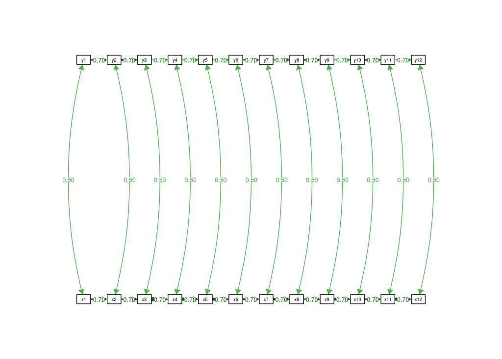

```r
someData <- simulateData(model=generatingModel, sample.nobs=250, empirical=T,
                         auto.fix.first = FALSE, auto.var = FALSE, auto.fix.single = FALSE,
                         auto.cov.lv.x = FALSE, auto.cov.y = FALSE)
fit.DGM <- lavaan(make_clpm_lavaan(generate = F), someData, fixed.x=F)
semPaths(fit.DGM, what='est', rotation=2, exoCov=T, exoVar=T, layout = 'tree2',
         residuals = F, structural = F, sizeLat = 3, sizeMan = 3, sizeMan2 = 2,
         intercepts = F, layoutSplit = F, bifactor = c('omega', 'kappa', paste0('q', 1:12)))
```

```r
# summary(fit.DGM, standardize=T)

someData_long <- someData %>%
  mutate(id = 1:n()) %>%
  gather(key, value, -id) %>%
  extract(key, c('var', 'wave'), '(x|y)(\\d+)') %>%
  spread(var, value) %>%
  mutate(wave = as.numeric(wave)) %>%
  arrange(id, wave)

someData_long$gmean_x <- mean(someData_long$x)
someData_long$gmean_y <- mean(someData_long$y)

someData_long <- someData_long %>%
  group_by(id) %>%
  mutate(x_lag = lag(x),
         y_lag = lag(y),
         id_mean_x = mean(x),
         wcen_x = x - id_mean_x,
         gcen_x = id_mean_x - gmean_x,
         wcen_x_lag = lag(wcen_x),
         id_mean_y = mean(y),
         wcen_y = y - id_mean_y,
         gcen_y = id_mean_y - gmean_y,
         wcen_y_lag = lag(wcen_y))
```

Now we can see what happens if we predict $y_{t}$ from $x_{t-1}$ without accounting for previous levels of y.

```r
lag1.misspec <- lme(y ~ 1 + x_lag, random = ~ 1 | id, data = someData_long,
                 na.action = na.omit)
summary(lag1.misspec)
```

```
## Linear mixed-effects model fit by REML
##   Data: someData_long
##        AIC      BIC    logLik
##   8727.472 8751.147 -4359.736
##
## Random effects:
##  Formula: ~1 | id
##         (Intercept) Residual
## StdDev:   0.6900746 1.092353
##
## Fixed effects:  y ~ 1 + x_lag
##                 Value  Std.Error   DF  t-value p-value
## (Intercept) 0.0000000 0.04836027 2499  0.00000       1
## x_lag       0.2798822 0.01872749 2499 14.94499       0
##  Correlation:
##       (Intr)
## x_lag 0
##
## Standardized Within-Group Residuals:
##          Min           Q1          Med           Q3          Max
## -3.690093447 -0.657384819  0.005562433  0.660133898  3.001607777
##
## Number of Observations: 2750
## Number of Groups: 250
```

We see a very robust effect of lagged x on y, even though no causal effect exists, by construction. This is due to the fact the x_lag is correlated with y_lag, and y_lag is correlated with y.

```r
lag1.ylag <- lme(y ~ 1 + y_lag + x_lag, random = ~ 1 | id, data = someData_long,
                 na.action = na.omit)
summary(lag1.ylag)
```

```
## Linear mixed-effects model fit by REML
##   Data: someData_long
##        AIC     BIC    logLik
##   7833.269 7862.86 -3911.634
##
## Random effects:
##  Formula: ~1 | id
##         (Intercept)  Residual
## StdDev:  0.03921928 0.9997851
##
## Fixed effects:  y ~ 1 + y_lag + x_lag
##                 Value  Std.Error   DF  t-value p-value
## (Intercept) 0.0000000 0.01922583 2498  0.00000       1
## y_lag       0.6980061 0.01650849 2498 42.28165       0
## x_lag       0.0000000 0.01650849 2498  0.00000       1
##  Correlation:
##       (Intr) y_lag
## y_lag  0.0
## x_lag  0.0   -0.5
##
## Standardized Within-Group Residuals:
##          Min           Q1          Med           Q3          Max
## -3.206085828 -0.660135290 -0.002539393  0.684186612  3.216006837
##
## Number of Observations: 2750
## Number of Groups: 250
```

Once we control for lagged y, which is the true causal effect, we see that lagged x does not have an influence on y

Can we use the residual autocorrelation structure in place of y_lag?

```r
lag1.yAR <-lme(y ~ 1 + x_lag, random = ~ 1 | id, data = someData_long,
               correlation = corAR1(form = ~ wave | id),
               na.action = na.omit)
summary(lag1.yAR)
```

```
## Linear mixed-effects model fit by REML
##   Data: someData_long
##        AIC      BIC   logLik
##   7929.139 7958.732 -3959.57
##
## Random effects:
##  Formula: ~1 | id
##         (Intercept) Residual
## StdDev:   0.1451315 1.343548
##
## Correlation Structure: AR(1)
##  Formula: ~wave | id
##  Parameter estimate(s):
##       Phi
## 0.6758963
## Fixed effects:  y ~ 1 + x_lag
##                  Value  Std.Error   DF  t-value p-value
## (Intercept) 0.00000000 0.05045094 2499 0.000000  1.0000
## x_lag       0.02840258 0.01930589 2499 1.471188  0.1414
##  Correlation:
##       (Intr)
## x_lag 0
##
## Standardized Within-Group Residuals:
##         Min          Q1         Med          Q3         Max
## -3.91725704 -0.66163857  0.01428189  0.67702765  3.25836115
##
## Number of Observations: 2750
## Number of Groups: 250
```

Including the residual AR structure helps, but we still see a positive estimate for the effect of x_lag. Since we’re working with data that reflects exactly the data generating model, we should get exactly the same numbers that we put in – so this positive estimate is cause for concern. How much does this inflate our false positive rate if we sample randomly from the data generating model (as we do when we run a study)?

If we’re just estimating contemporaneous effects without allowing for possible lagged causes what do we get?

```r
cont1.y <-lme(y ~ 1 + x, random = ~ 1 | id, data = someData_long,
              na.action = na.omit)
summary(cont1.y)
```

```
## Linear mixed-effects model fit by REML
##   Data: someData_long
##        AIC      BIC    logLik
##   8825.798 8849.821 -4408.899
##
## Random effects:
##  Formula: ~1 | id
##         (Intercept) Residual
## StdDev:   0.6377892 0.973903
##
## Fixed effects:  y ~ 1 + x
##             Value  Std.Error   DF  t-value p-value
## (Intercept)   0.0 0.04408245 2749  0.00000       1
## x             0.5 0.01581666 2749 31.61223       0
##  Correlation:
##   (Intr)
## x 0
##
## Standardized Within-Group Residuals:
##         Min          Q1         Med          Q3         Max
## -3.76816405 -0.66150052  0.00708758  0.66067798  3.17562601
##
## Number of Observations: 3000
## Number of Groups: 250
```

```r
cont1.yAR <-lme(y ~ 1 + x, random = ~ 1 | id, data = someData_long,
               correlation = corAR1(form = ~ wave | id),
               na.action = na.omit)
summary(cont1.yAR)
```

```
## Linear mixed-effects model fit by REML
##   Data: someData_long
##       AIC      BIC   logLik
##   7710.68 7740.708 -3850.34
##
## Random effects:
##  Formula: ~1 | id
##         (Intercept) Residual
## StdDev: 0.002047435 1.151257
##
## Correlation Structure: AR(1)
##  Formula: ~wave | id
##  Parameter estimate(s):
##       Phi
## 0.6742304
## Fixed effects:  y ~ 1 + x
##             Value  Std.Error   DF  t-value p-value
## (Intercept)   0.0 0.04108793 2749  0.00000       1
## x             0.5 0.01581666 2749 31.61223       0
##  Correlation:
##   (Intr)
## x 0
##
## Standardized Within-Group Residuals:
##         Min          Q1         Med          Q3         Max
## -4.22815949 -0.67944627 -0.01476893  0.68145712  3.30588675
##
## Number of Observations: 3000
## Number of Groups: 250
```

This looks right, ’cause this is very close to the generating model with no possible confounds.

# Simulations

## How the simulations work

Every simulation has a null cross-lag: over 12 waves, x and y are each stable (.7) and correlated within each wave (.5), but neither affects the other. The data come from three data-generating models, which are the three colors in every plot:

- the CLPM (gray), with no stable differences between people (trait variance 0; the same generator as the 2018 runs);
- the RI-CLPM with trait variance .5 (blue);
- the RI-CLPM with trait variance 1 (orange).

Every model below is fit to data from all three, except the RI-CLPM itself, which is only fit to the RI-CLPM data (on CLPM data its trait variances would sit at zero). For each data-generating model and each sample size (N = 30, 70, 110, 150, 300, 450, 600, 750, 900, 1050), `sim_riclpm.R` draws 10,000 datasets, fits each model below, and records the estimate and *p*-value for lagged x. A fit that errors or doesn’t converge counts as a failure and is left out of that cell (the table at the end shows how many); fits that only raise warnings are kept. With 10,000 replications, the Monte Carlo SE of a rate near .05 is about .002; the error bars in the plots span about ±2 SE. The 2018 runs used `lmeControl(opt = "optim")`, which stopped short of the maximum around N = 300 and made a spurious spike there for centered x with AR(1); these runs use nlme’s default optimizer, which fixes that.

```r
if(results_dir != 'riclpm_sims_r10000'){
  cat('\n\n**Note: this page was rendered from `', results_dir, '`, not the published results in `riclpm_sims_r10000`.**\n\n', sep = '')
}
```

The data generation and model fitting code is below. `sim_riclpm.R` reuses these definitions (and the generators above), and adds the naive model, the within/between model, and the RI-CLPM fit. Running it (`Rscript sim_riclpm.R 10000 <cores>`) writes the summary this page reads, `riclpm_sims_summary.RDS`, into the folder named in `results_dir` at the top.

```r
generate_data <- function(n = 250, gen_mod, wcen = FALSE){
  someData <- simulateData(model=gen_mod, sample.nobs=n, empirical=F)

  someData_long <- someData %>%
    mutate(id = 1:n()) %>%
    gather(key, value, -id) %>%
    extract(key, c('var', 'wave'), '(x|y)(\\d+)') %>%
    spread(var, value) %>%
    mutate(wave = as.numeric(wave)) %>%
    arrange(id, wave) %>%
    group_by(id) %>%
    mutate(x_lag = lag(x),
           y_lag = lag(y))

  if(wcen){
    someData_long$gmean_x <- mean(someData_long$x)
    someData_long$gmean_y <- mean(someData_long$y)
    someData_long <- someData_long %>%
      group_by(id) %>%
      mutate(id_mean_x = mean(x),
             wcen_x = x - id_mean_x,
             gcen_x = id_mean_x - gmean_x,
             wcen_x_lag = lag(wcen_x),
             id_mean_y = mean(y),
             wcen_y = y - id_mean_y,
             gcen_y = id_mean_y - gmean_y,
             wcen_y_lag = lag(wcen_y))
  }

  return(someData_long)
}

run_model <- function(n = 250, gen_mod, wcen = FALSE, use_lag_y = FALSE, use_lme4 = FALSE, wcen_re = FALSE){
  someData_long <- generate_data(n = n, gen_mod = gen_mod, wcen = wcen)

  if(wcen){
    if(use_lag_y){
      if(use_lme4){
        if(wcen_re){
          lag1.yAR <-lmer(y ~ 1 + wcen_y_lag + wcen_x_lag + gcen_x + (1 + wcen_x_lag || id), data = someData_long,
                          REML = TRUE,
                          na.action = na.omit)
        } else {
          lag1.yAR <-lmer(y ~ 1 + wcen_y_lag + wcen_x_lag + gcen_x + (1 | id), data = someData_long,
                          REML = TRUE,
                          na.action = na.omit)
        }
      } else {
        lag1.yAR <-lme(y ~ 1 + wcen_y_lag + wcen_x_lag + gcen_x, random = ~ 1 | id, data = someData_long,
                       na.action = na.omit)
      }
    } else {
      lag1.yAR <-lme(y ~ 1 + wcen_x_lag + gcen_x, random = ~ 1 | id, data = someData_long,
                     correlation = corAR1(form = ~ wave | id),
                     na.action = na.omit)
    }
    if(use_lme4){
      asum <- coef(summary(lag1.yAR, ddf = 'Satterthwaite'))
      x_lag_p <- asum['wcen_x_lag', 'Pr(>|t|)']
      x_lag_bias <- asum['wcen_x_lag', 'Estimate']
    } else {
      asum <- summary(lag1.yAR)
      x_lag_p <- asum$tTable['wcen_x_lag', 'p-value']
      x_lag_bias <- asum$tTable['wcen_x_lag', 'Value']
    }
  } else {
    if(use_lag_y){
      lag1.yAR <-lme(y ~ 1 + y_lag + x_lag, random = ~ 1 | id, data = someData_long,
                     na.action = na.omit)
    } else {
      lag1.yAR <-lme(y ~ 1 + x_lag, random = ~ 1 | id, data = someData_long,
                     correlation = corAR1(form = ~ wave | id),
                     na.action = na.omit)
    }

    asum <- summary(lag1.yAR)
    x_lag_p <- asum$tTable['x_lag', 'p-value']
    x_lag_bias <- asum$tTable['x_lag', 'Value']
  }
  return(data.frame(n = n, x_lag_p = x_lag_p, x_lag_bias = x_lag_bias))
}
```

## The naive model

```
lag1.naive <- lme(y ~ 1 + x_lag, random = ~ 1 | id, data = someData_long,
                  na.action = na.omit)
```

This is the first model in the demonstration above, with nothing to account for the stability of y.

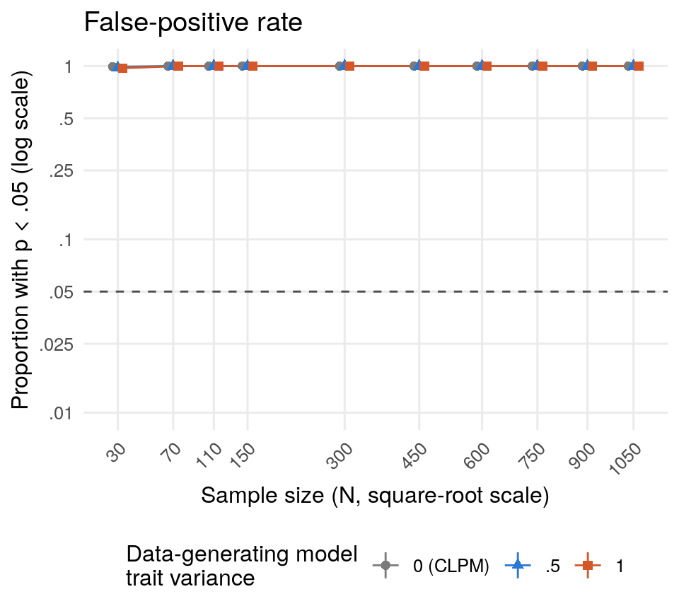

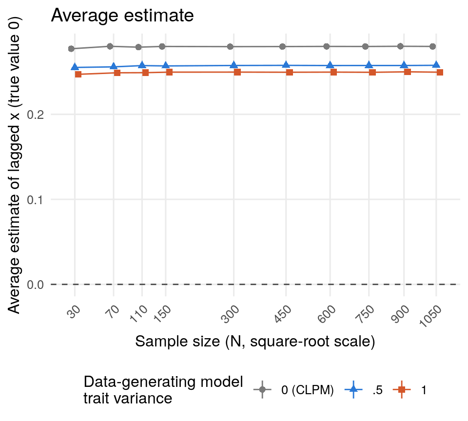

```r
plot_spec('naive')
```

## The within/between model

```
lag1.sea <- lme(y ~ 1 + wcen_x_lag + gcen_x + time_c, random = ~ 1 | id, data = someData_long,
                na.action = na.omit)
```

This is a common way to set up month-level lagged analyses: x is split into each person’s deviation from their own mean (lagged one month) and their mean itself (grand-mean centered), with a time term and a random intercept (Curran and Bauer 2011; Wang and Maxwell 2015). It’s often fit in brms with weak priors; here it’s fit with lme, which should give essentially the same estimates. Like the naive model, it has nothing for the prior month’s y.

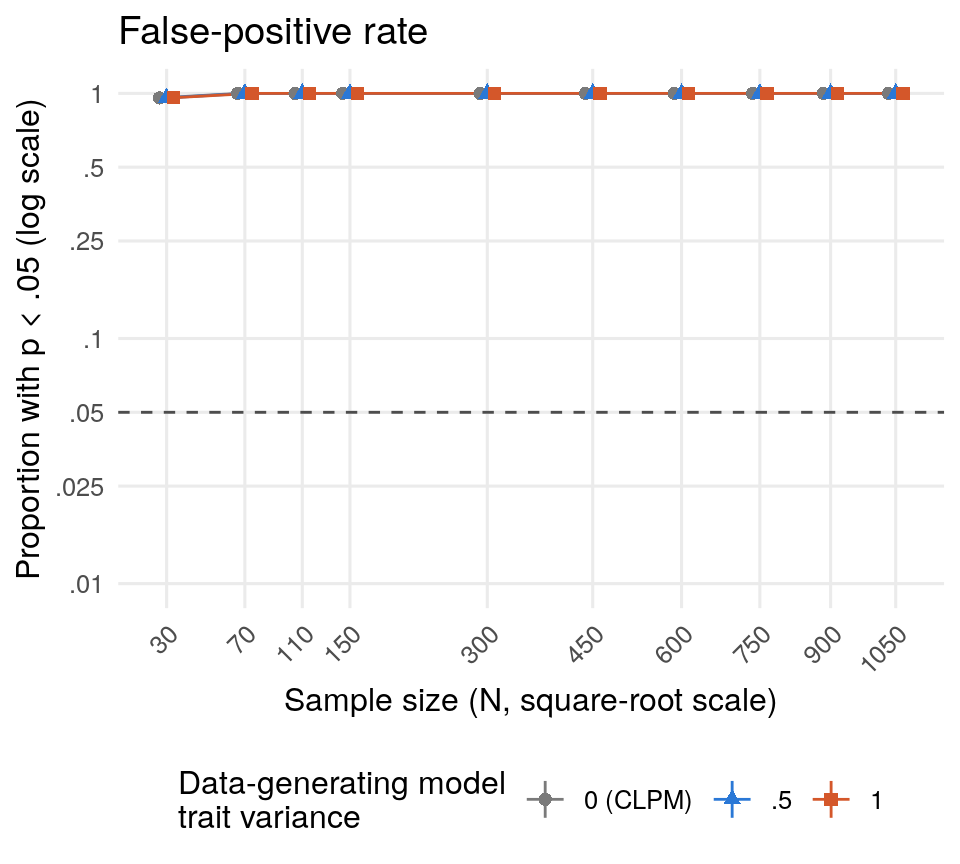

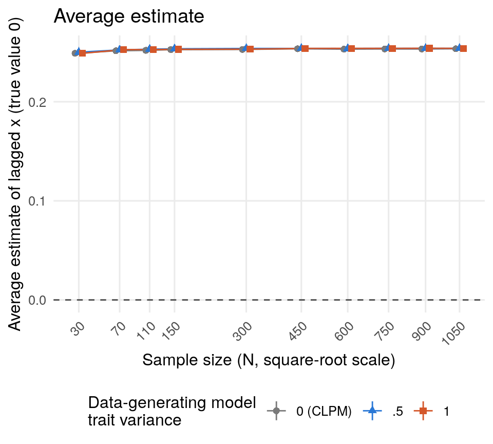

```r
plot_spec('sea')
```

## Using AR residual structure to account for stability

```
lag1.yAR <-lme(y ~ 1 + x_lag, random = ~ 1 | id, data = someData_long,
               correlation = corAR1(form = ~ wave | id),
               na.action = na.omit)
```

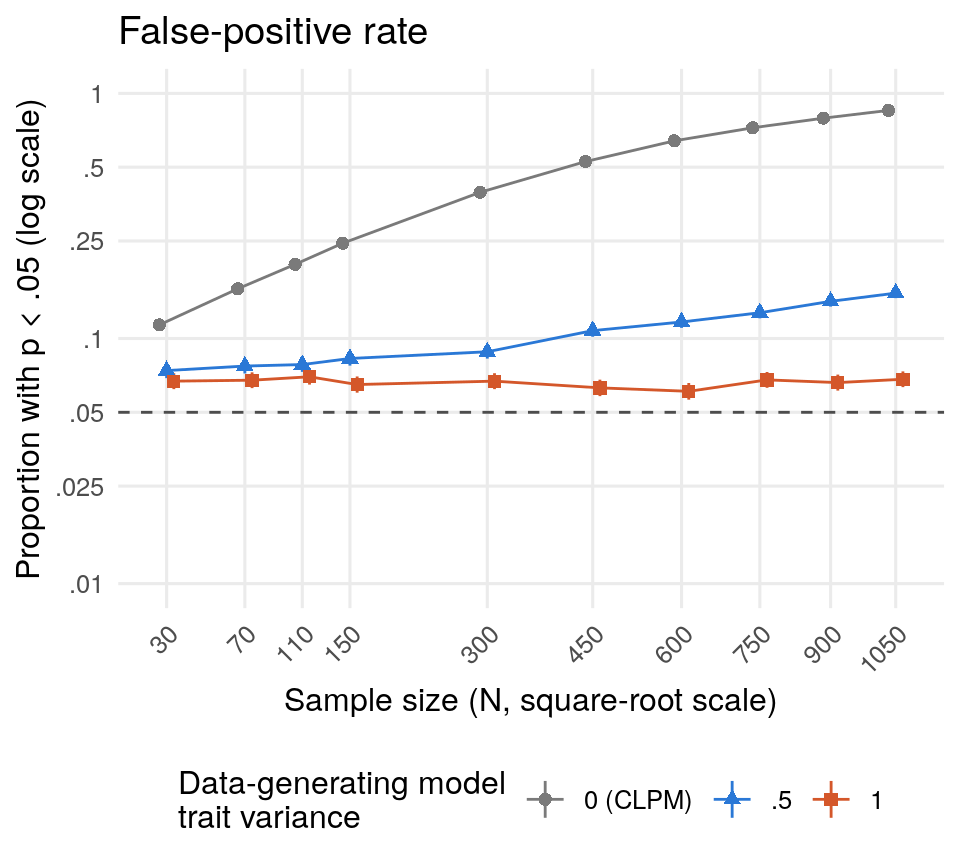

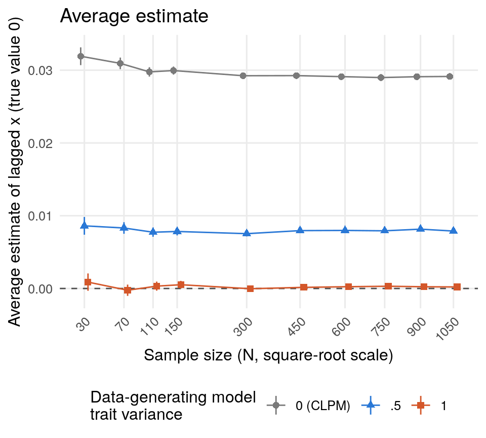

```r
plot_spec('no_wcen_ar')
```

What we see here on the CLPM data (gray) is a consistent bias in the estimates of the effect of lagged x on y. As our sample size increases, we are better and better powered, which means we erroneously reject the null more often due to this bias. In other words, if we are powered to detect an effect of lagged x on y, we are powered to mistake this bias for a causal effect, even using the AR structure to adjust for the stability of y. (The trait data behave differently; see “What’s going on?” below.)

## Using lagged DV to account for stability

```
lag1.yAR <-lme(y ~ 1 + y_lag + x_lag, random = ~ 1 | id, data = someData_long,
               na.action = na.omit)
```

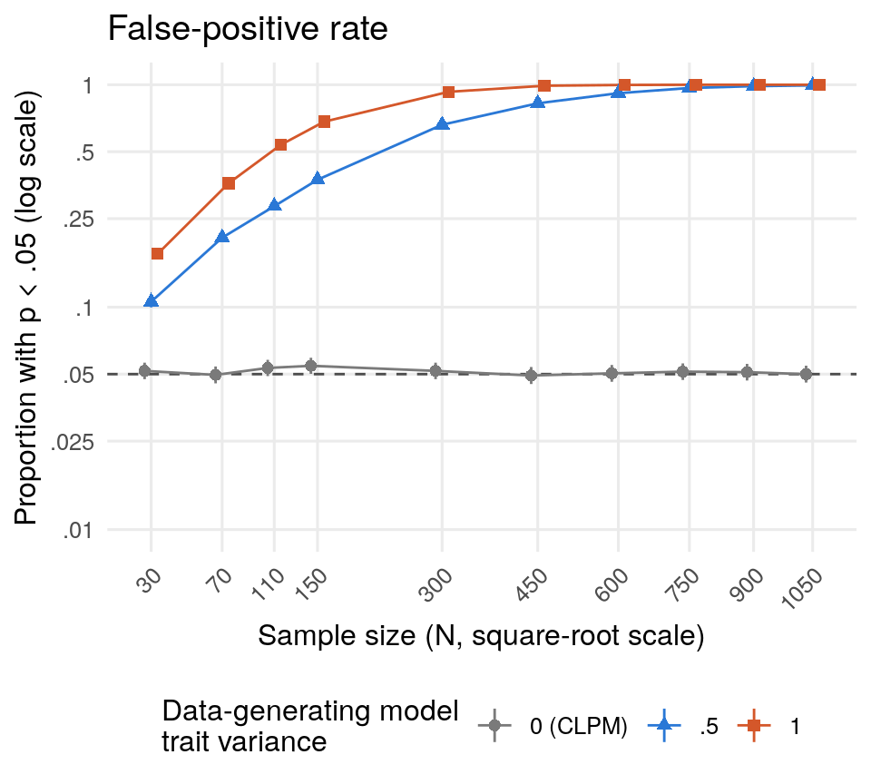

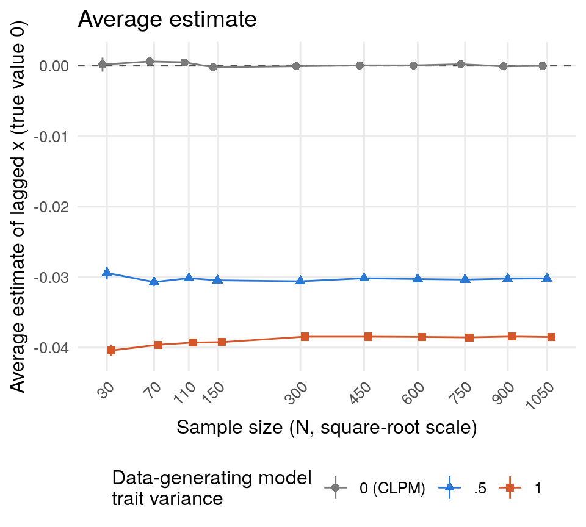

```r
plot_spec('no_wcen_ylag')
```

On the CLPM data, we see no bias in the estimate of the effect of lagged x on y, and correspondingly our error rate is controlled appropriately. With stable traits, though, the estimate is biased negative, and the error rate climbs with N.

## AR with within-person-centering

We might want to create separate IVs for the within-person versus the between-person effect. In this example, I’ve created a variable that is just each person’s mean across all waves, centered at the group mean (gcen) and a within-person variable that is each person’s score at a wave minus their mean.

This is in line with the advice in:

> Wang, L. (Peggy), & Maxwell, S. E. (2015). On disaggregating between-person and within-person effects with longitudinal data using multilevel models. Psychological Methods, 20(1), 63–83. https://doi.org/10.1037/met0000030

```
lag1.yAR <-lme(y ~ 1 + wcen_x_lag + gcen_x, random = ~ 1 | id, data = someData_long,
               correlation = corAR1(form = ~ wave | id),
               na.action = na.omit)
```

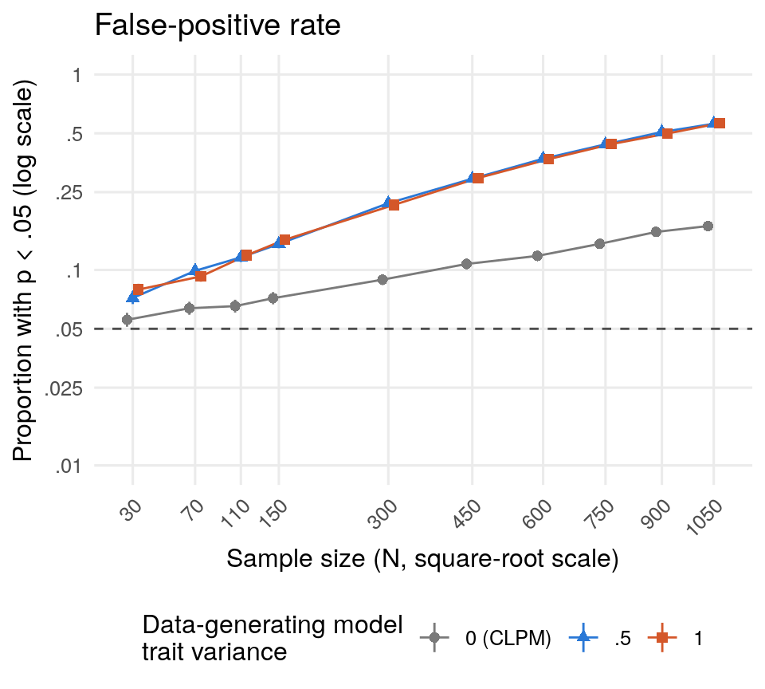

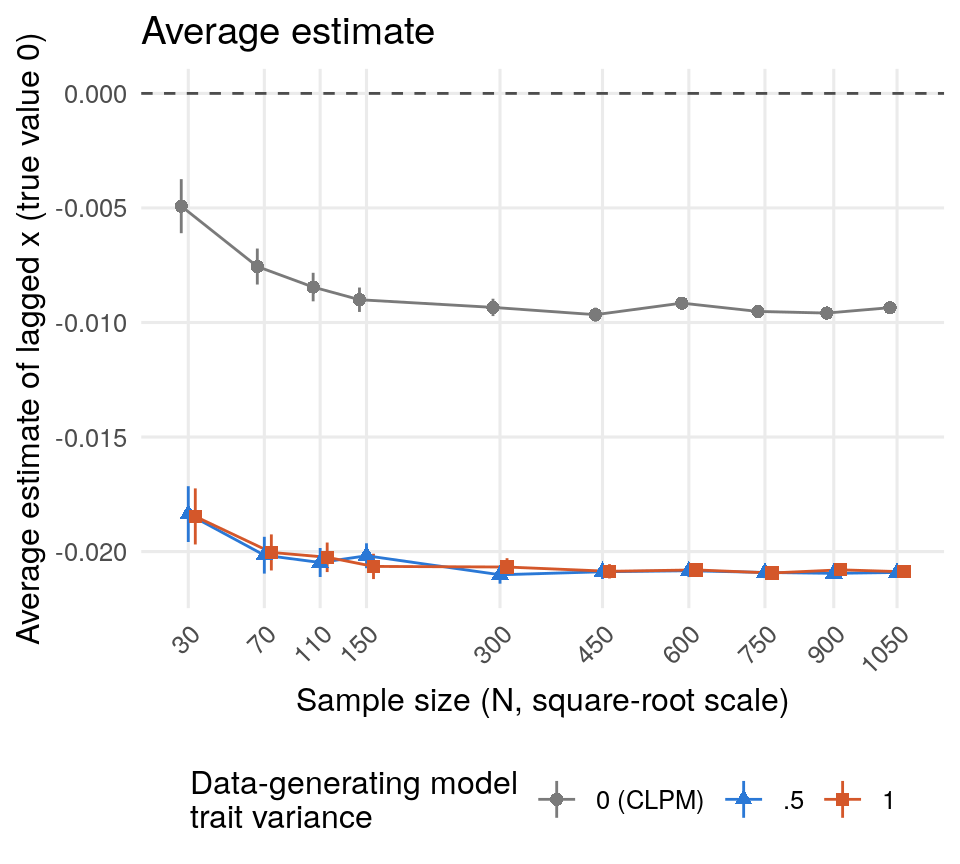

```r
plot_spec('wcen_ar')
```

Interestingly, when we within-person center the lagged x variable, we see a negative bias. This is also picked up in the p-values as our sample size increases.

## Lagged y with within-person-centering

Note that when we within-person center the IV, x, we also within-person center the lagged DV, y, and include that (the between-person component of y is redundant with the random intercept). If you don’t do this, wow, the false positive error rate goes way up. I’m not quite sure why this is (see next sim).

```
lag1.yAR <-lme(y ~ 1 + wcen_y_lag + wcen_x_lag + gcen_x, random = ~ 1 | id, data = someData_long,
               na.action = na.omit)
```

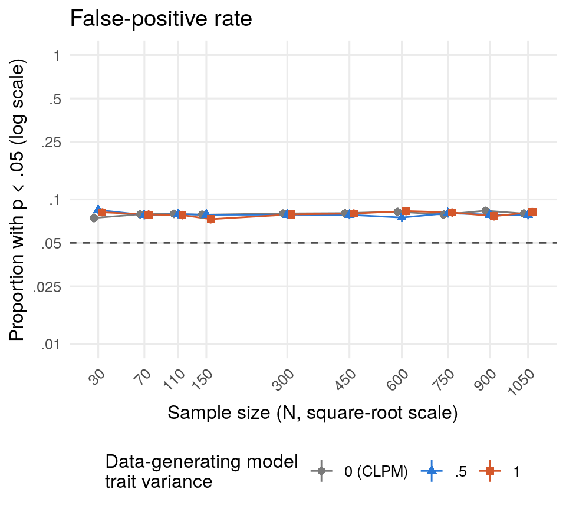

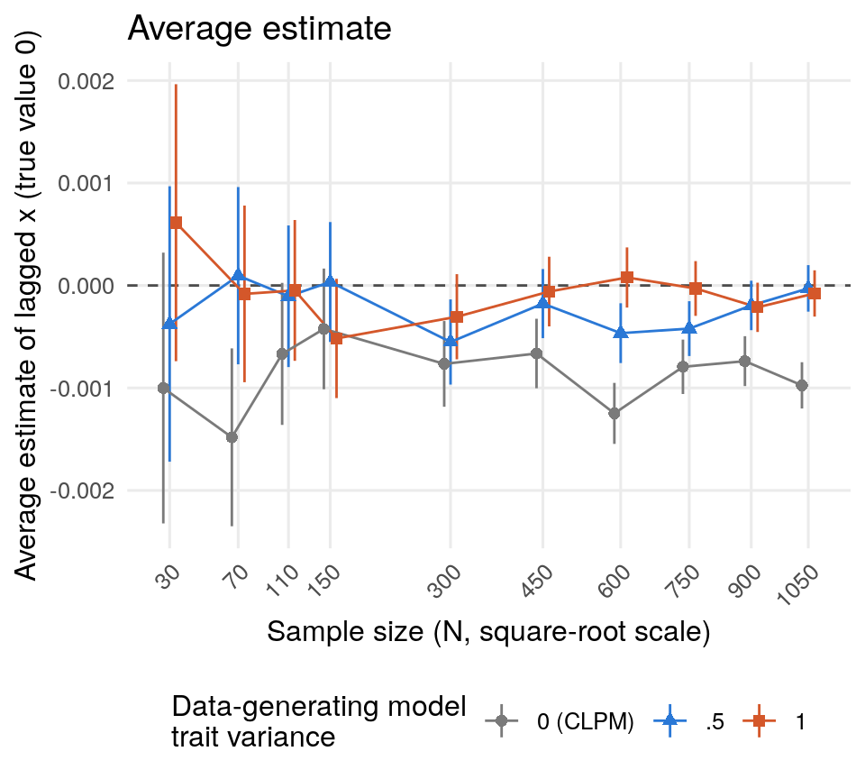

```r
plot_spec('wcen_ylag')
```

The error rate in this case is still higher than the nominal rate, but since bias is 0, this may be due to a problem with the standard errors, or the DF being used. Perhaps another possibility is that the random effects are misspecified. I’m not sure why this is, but we can test whether using the Satterthwaite correction, or including a random effect of the within-person predictor helps.

## Centered x with raw lagged y

```
lag1.rawy <- lme(y ~ 1 + y_lag + wcen_x_lag + gcen_x, random = ~ 1 | id, data = someData_long,
                 na.action = na.omit)
```

This is what happens if you center x but leave the lagged outcome raw.

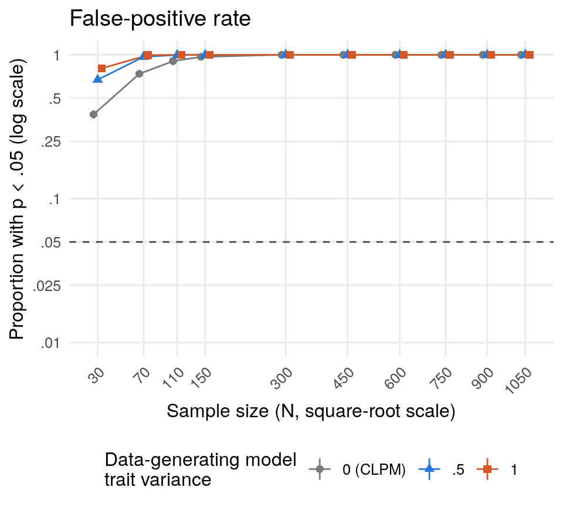

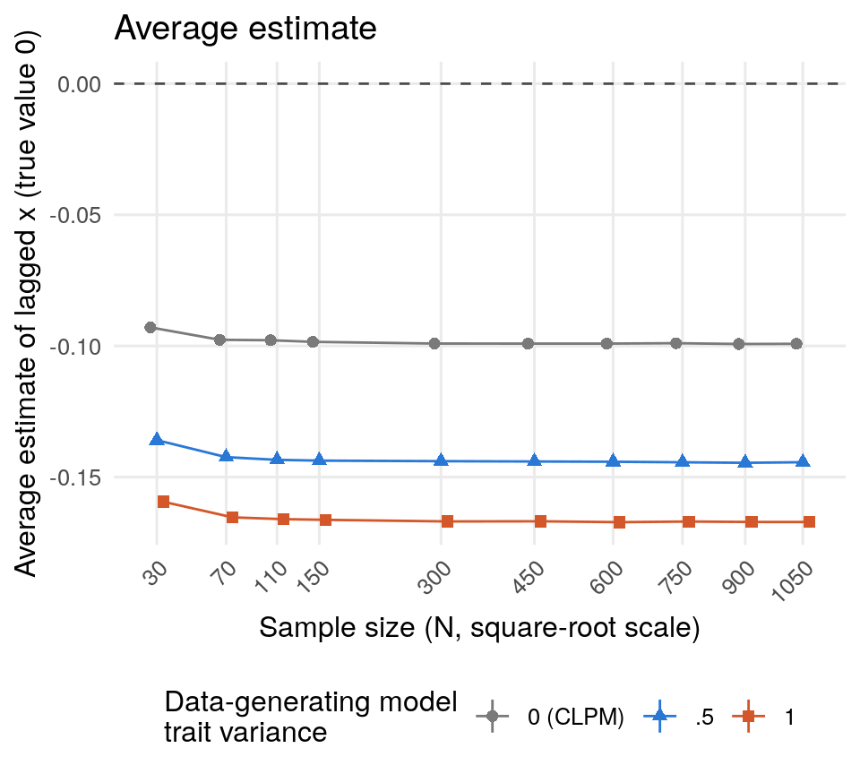

```r
plot_spec('wcen_x_raw_ylag')
```

My best guess at why: each person’s mean of x is taken over all 12 waves, including this month, so centered lagged x carries a little of this month’s shock to x (with a minus sign), and this month’s shock to x is correlated with this month’s shock to y. Centered lagged y carries the same kind of piece of this month’s y, which seems to soak most of that up; raw lagged y doesn’t, so lagged x picks it up as a negative effect. I haven’t checked this beyond these simulations.

## Lagged y with within-person-centering, Satterthwaite correction

Perhaps using the Satterthwaite correction will appropriately adjust the *p*-values.

```
lag1.yAR <-lmer(y ~ 1 + wcen_y_lag + wcen_x_lag + gcen_x + (1 | id), data = someData_long,
               REML = TRUE,
               na.action = na.omit)
summary(lag1.yAR, ddf = 'Satterthwaite')
```

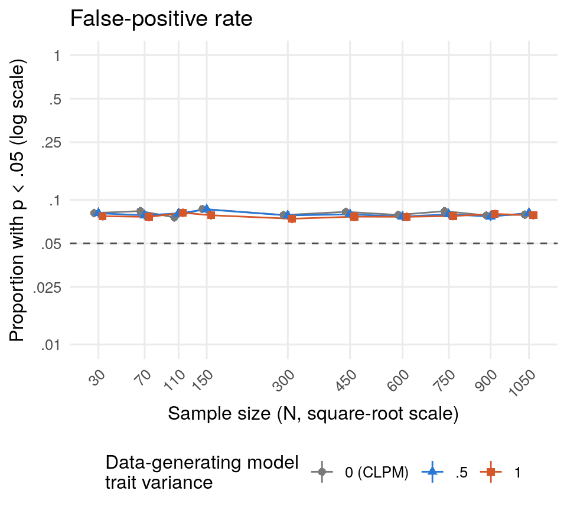

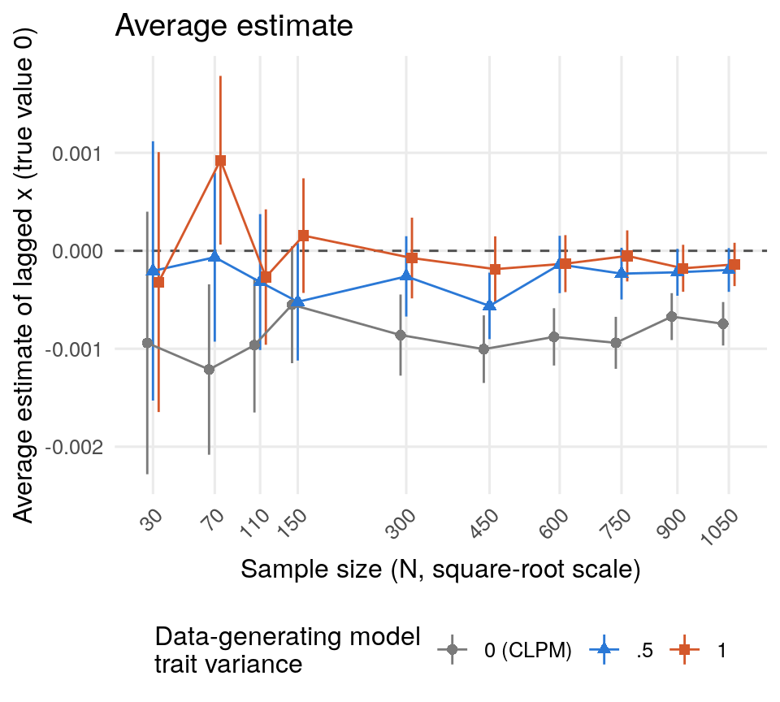

```r
plot_spec('wcen_ylag_l4')
```

Bummer. Still a higher than expected error rate.

## Lagged y with within-person-centering, Satterthwaite correction + WCEN RE

The last thing I’ll try is to add the within-person centered lagged predictor as random effect.

```
lag1.yAR <-lmer(y ~ 1 + wcen_y_lag + wcen_x_lag + gcen_x + (1 + wcen_x_lag || id), data = someData_long,
               REML = TRUE,
               na.action = na.omit)
summary(lag1.yAR, ddf = 'Satterthwaite')
```

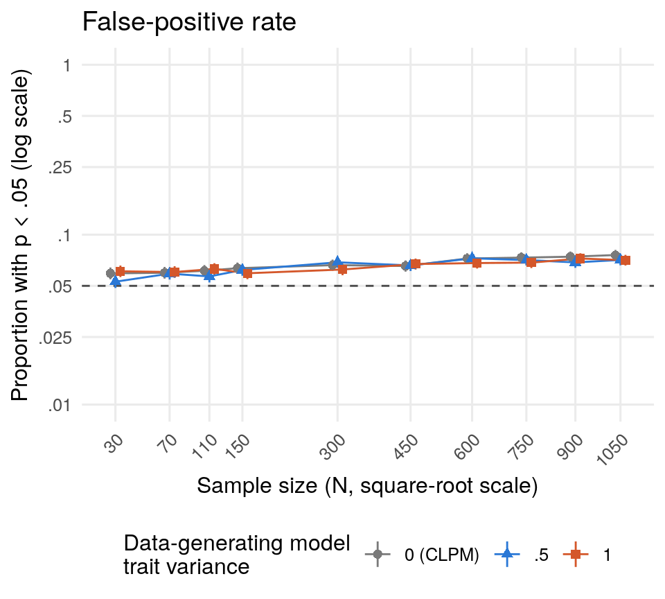

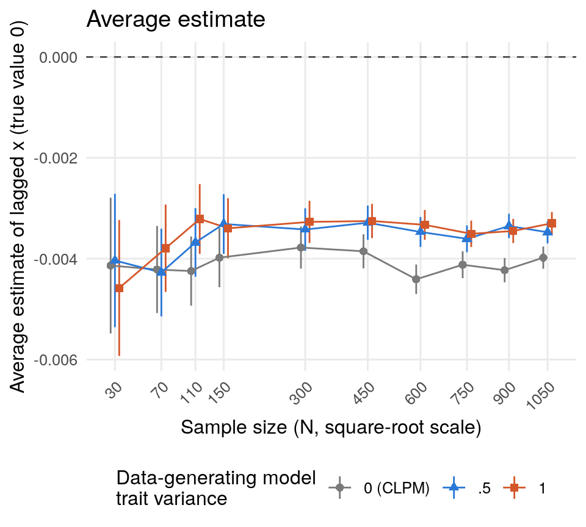

```r
plot_spec('wcen_ylag_l4_wcenre')
```

That looks like it helped a little bit, but it also seems to induce a small negative bias.

## The RI-CLPM

```
riclpm_fit_text <- riclpmr::riclpm_text(list(x = paste0("x", 1:12), y = paste0("y", 1:12)),
                                        constrain_over_waves = TRUE)
fit <- riclpmr::lavriclpm(riclpmModel = riclpm_fit_text, data = someData)
```

Last, the RI-CLPM itself, fit to the wide data with riclpmr, with each path constrained equal over waves (for a walk-through of the model, see [my RI-CLPM tutorial](https://johnflournoy.science/riclpm-lavaan-demo.html)). The estimate is the path from x at *t* − 1 to y at *t*. It’s the true model for the trait data, so it’s the benchmark here. It isn’t fit to the CLPM data, where its trait variances would sit at their boundary of zero.

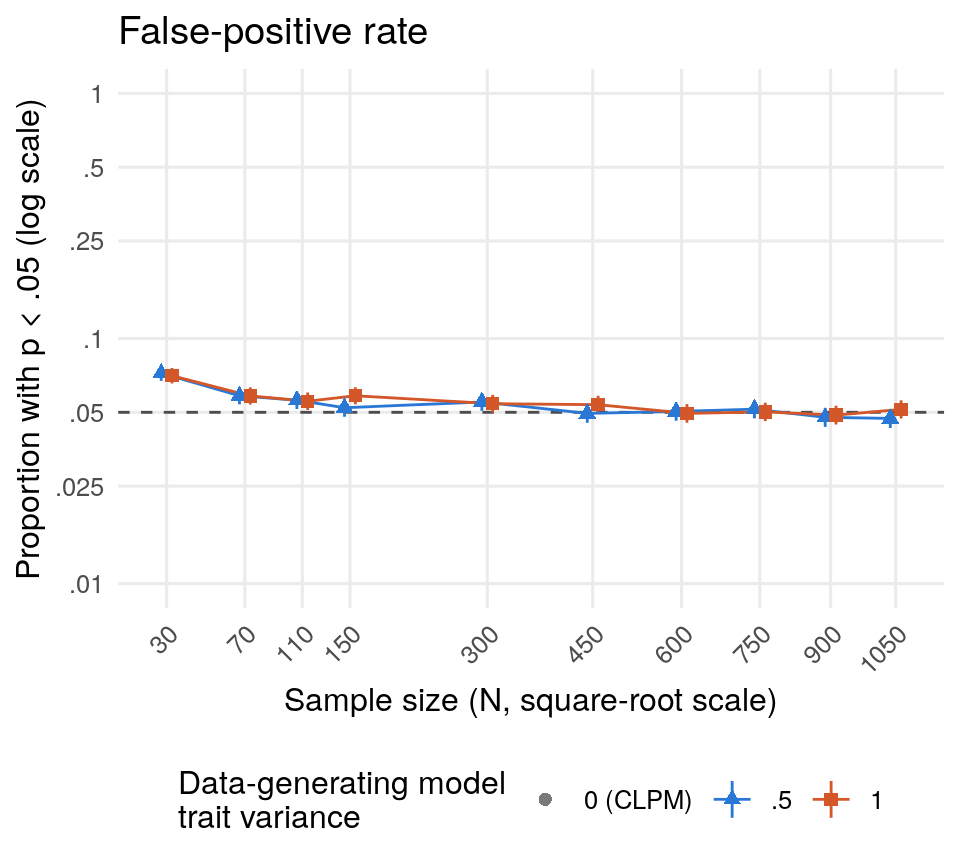

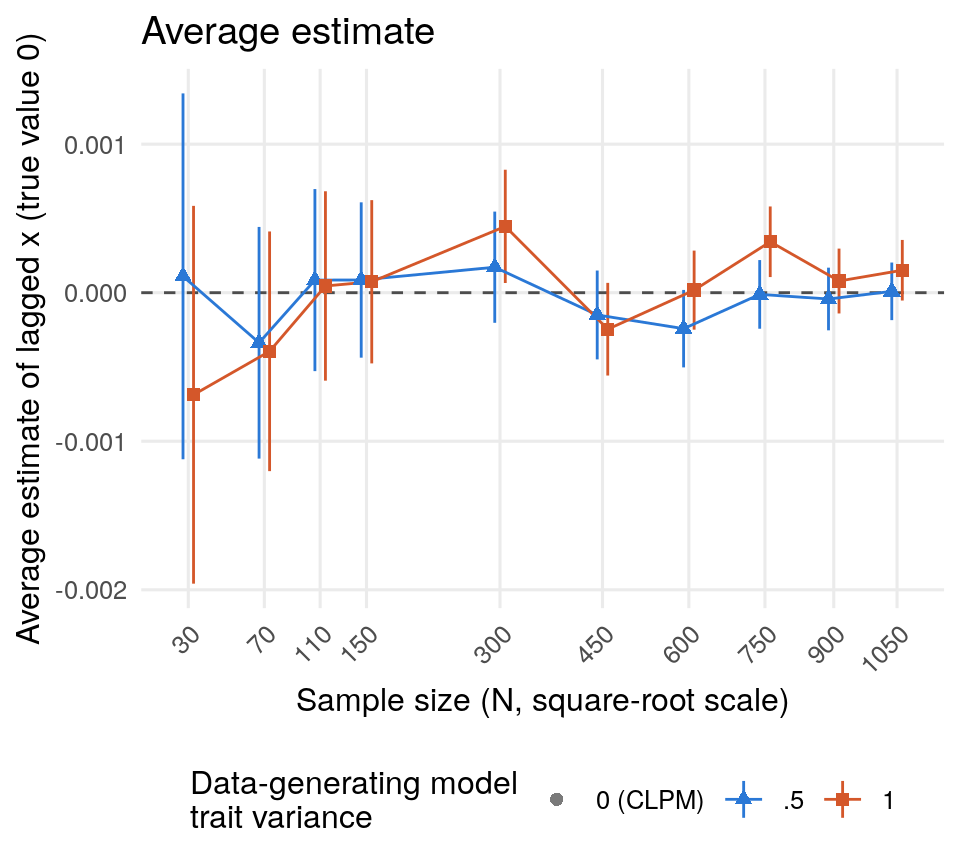

```r
plot_spec('riclpm')
```

## The results in two tables

```r
table_n <- c(30, 300, max_n)
tab_cells <- sim_sum[sim_sum$n %in% table_n, ]
tab_cells$cell_fp <- f3(tab_cells$fp_rate)
tab_cells$cell_est <- f3(tab_cells$mean_est)
rate_wide <- tab_cells %>%
  mutate(col = paste0('rate, N = ', n)) %>%
  select(spec, trait_var, col, cell_fp) %>%
  spread(col, cell_fp)
est_wide <- tab_cells %>%
  mutate(col = paste0('estimate, N = ', n)) %>%
  select(spec, trait_var, col, cell_est) %>%
  spread(col, cell_est)
results_table <- dplyr::inner_join(rate_wide, est_wide, by = c('spec', 'trait_var'))
if(nrow(results_table) != nrow(expected_cells) / length(N_seq)) stop('Results table lost or gained rows in the join.')
results_table <- results_table %>%
  mutate(model = factor(spec_labels[spec], levels = spec_labels),
         `data-generating trait variance` = factor(trait_label(trait_var), levels = trait_levels)) %>%
  arrange(model, `data-generating trait variance`) %>%
  select(model, `data-generating trait variance`, paste0('rate, N = ', table_n), paste0('estimate, N = ', table_n))
print(knitr::kable(results_table, align = c('l', 'l', rep('r', 2 * length(table_n))),
                   caption = paste0('Proportion of replications with p < .05 for lagged x (nominal .05), and the average estimate ',
                                    '(true value 0), at three sample sizes. ', format(expected_reps, big.mark = ','),
                                    ' replications per cell.')))
```

Proportion of replications with p < .05 for lagged x (nominal .05), and the average estimate (true value 0), at three sample sizes. 10,000 replications per cell.

| model | data-generating trait variance | rate, N = 30 | rate, N = 300 | rate, N = 1050 | estimate, N = 30 | estimate, N = 300 | estimate, N = 1050 |
| --- | --- | --- | --- | --- | --- | --- | --- |
| y ~ x_lag (naive) | 0 (CLPM) | .990 | 1.000 | 1.000 | .277 | .280 | .280 |
| y ~ x_lag (naive) | .5 | .977 | 1.000 | 1.000 | .255 | .257 | .258 |
| y ~ x_lag (naive) | 1 | .973 | 1.000 | 1.000 | .247 | .250 | .250 |
| centered x_lag + person mean + time (within/between) | 0 (CLPM) | .958 | 1.000 | 1.000 | .249 | .253 | .254 |
| centered x_lag + person mean + time (within/between) | .5 | .959 | 1.000 | 1.000 | .250 | .254 | .254 |
| centered x_lag + person mean + time (within/between) | 1 | .961 | 1.000 | 1.000 | .249 | .253 | .254 |
| y ~ x_lag, AR(1) | 0 (CLPM) | .114 | .395 | .852 | .032 | .029 | .029 |
| y ~ x_lag, AR(1) | .5 | .074 | .088 | .153 | .009 | .008 | .008 |
| y ~ x_lag, AR(1) | 1 | .067 | .067 | .068 | .001 | .000 | .000 |
| y ~ y_lag + x_lag | 0 (CLPM) | .052 | .052 | .050 | .000 | .000 | .000 |
| y ~ y_lag + x_lag | .5 | .106 | .661 | .993 | -.029 | -.031 | -.030 |
| y ~ y_lag + x_lag | 1 | .174 | .929 | 1.000 | -.040 | -.038 | -.039 |
| centered x_lag, AR(1) | 0 (CLPM) | .056 | .089 | .168 | -.005 | -.009 | -.009 |
| centered x_lag, AR(1) | .5 | .072 | .220 | .560 | -.018 | -.021 | -.021 |
| centered x_lag, AR(1) | 1 | .079 | .215 | .563 | -.018 | -.021 | -.021 |
| centered y_lag + x_lag (nlme) | 0 (CLPM) | .074 | .080 | .080 | -.001 | -.001 | -.001 |
| centered y_lag + x_lag (nlme) | .5 | .084 | .078 | .078 | .000 | -.001 | .000 |
| centered y_lag + x_lag (nlme) | 1 | .081 | .079 | .082 | .001 | .000 | .000 |
| raw y_lag + centered x_lag | 0 (CLPM) | .385 | 1.000 | 1.000 | -.093 | -.099 | -.099 |
| raw y_lag + centered x_lag | .5 | .671 | 1.000 | 1.000 | -.136 | -.144 | -.144 |
| raw y_lag + centered x_lag | 1 | .807 | 1.000 | 1.000 | -.159 | -.167 | -.167 |
| centered y_lag + x_lag (lme4, Satterthwaite) | 0 (CLPM) | .081 | .078 | .079 | -.001 | -.001 | -.001 |
| centered y_lag + x_lag (lme4, Satterthwaite) | .5 | .081 | .078 | .081 | .000 | .000 | .000 |
| centered y_lag + x_lag (lme4, Satterthwaite) | 1 | .077 | .074 | .078 | .000 | .000 | .000 |
| centered y_lag + x_lag (lme4, Satterthwaite, random slope) | 0 (CLPM) | .059 | .066 | .076 | -.004 | -.004 | -.004 |
| centered y_lag + x_lag (lme4, Satterthwaite, random slope) | .5 | .053 | .069 | .071 | -.004 | -.003 | -.003 |
| centered y_lag + x_lag (lme4, Satterthwaite, random slope) | 1 | .061 | .062 | .071 | -.005 | -.003 | -.003 |
| RI-CLPM | .5 | .072 | .055 | .047 | .000 | .000 | .000 |
| RI-CLPM | 1 | .070 | .054 | .051 | -.001 | .000 | .000 |

```r
problem_table <- sim_sum %>%
  group_by(spec, trait_var) %>%
  summarize(failed_total = sum(failed),
            failed_max = max(failed),
            failed_max_n = paste(n[failed == max(failed)], collapse = ', '),
            warn_total = sum(reps_with_warnings),
            warn_max = max(reps_with_warnings),
            warn_max_n = paste(n[reps_with_warnings == max(reps_with_warnings)], collapse = ', '),
            .groups = 'drop') %>%
  filter(failed_total > 0 | warn_total > 0) %>%
  mutate(model = factor(spec_labels[spec], levels = spec_labels),
         `data-generating trait variance` = factor(trait_label(trait_var), levels = trait_levels),
         `failed fits` = failed_total,
         `most failures in one cell (N)` = ifelse(failed_total > 0, paste0(failed_max, ' (', failed_max_n, ')'), ''),
         `fits with warnings` = warn_total,
         `most warnings in one cell (N)` = ifelse(warn_total > 0, paste0(warn_max, ' (', warn_max_n, ')'), '')) %>%
  arrange(model, `data-generating trait variance`) %>%
  select(model, `data-generating trait variance`, `failed fits`, `most failures in one cell (N)`, `fits with warnings`, `most warnings in one cell (N)`)
if(nrow(problem_table) == 0){
  cat('\n\nNo fit failed or raised a warning in any cell.\n\n')
} else {
  print(knitr::kable(problem_table, align = c('l', 'l', 'r', 'r', 'r', 'r'),
                     caption = paste0('Fits that failed (errors or non-convergence; left out of that cell) and fits that raised ',
                                      'at least one warning (kept), summed over the ', length(N_seq), ' sample sizes, out of ',
                                      format(expected_reps * length(N_seq), big.mark = ','),
                                      ' per row. Rows with neither are left out.')))
}
```

Fits that failed (errors or non-convergence; left out of that cell) and fits that raised at least one warning (kept), summed over the 10 sample sizes, out of 100,000 per row. Rows with neither are left out.

| model | data-generating trait variance | failed fits | most failures in one cell (N) | fits with warnings | most warnings in one cell (N) |
| --- | --- | --- | --- | --- | --- |
| y ~ x_lag (naive) | 0 (CLPM) | 752 | 325 (1050) | 0 |  |
| y ~ x_lag (naive) | .5 | 696 | 266 (1050) | 0 |  |
| y ~ x_lag (naive) | 1 | 621 | 278 (1050) | 0 |  |
| centered x_lag + person mean + time (within/between) | 0 (CLPM) | 727 | 315 (1050) | 0 |  |
| centered x_lag + person mean + time (within/between) | .5 | 687 | 280 (1050) | 0 |  |
| centered x_lag + person mean + time (within/between) | 1 | 696 | 274 (1050) | 0 |  |
| y ~ x_lag, AR(1) | 0 (CLPM) | 16 | 9 (1050) | 0 |  |
| y ~ y_lag + x_lag | 0 (CLPM) | 7 | 4 (900) | 0 |  |
| y ~ y_lag + x_lag | .5 | 10 | 5 (900) | 0 |  |
| y ~ y_lag + x_lag | 1 | 10 | 7 (900) | 0 |  |
| centered x_lag, AR(1) | 0 (CLPM) | 13 | 10 (1050) | 0 |  |
| centered y_lag + x_lag (nlme) | 0 (CLPM) | 703 | 307 (1050) | 0 |  |
| centered y_lag + x_lag (nlme) | .5 | 734 | 259 (1050) | 0 |  |
| centered y_lag + x_lag (nlme) | 1 | 717 | 291 (1050) | 0 |  |
| raw y_lag + centered x_lag | 0 (CLPM) | 7 | 5 (900) | 0 |  |
| raw y_lag + centered x_lag | .5 | 7 | 5 (1050) | 0 |  |
| raw y_lag + centered x_lag | 1 | 4 | 3 (1050) | 0 |  |
| centered y_lag + x_lag (lme4, Satterthwaite) | 0 (CLPM) | 0 |  | 2 | 2 (900) |
| centered y_lag + x_lag (lme4, Satterthwaite) | .5 | 0 |  | 4 | 2 (30, 110) |
| centered y_lag + x_lag (lme4, Satterthwaite) | 1 | 0 |  | 6 | 2 (30, 300) |
| centered y_lag + x_lag (lme4, Satterthwaite, random slope) | 0 (CLPM) | 0 |  | 893 | 202 (1050) |
| centered y_lag + x_lag (lme4, Satterthwaite, random slope) | .5 | 0 |  | 778 | 129 (1050) |
| centered y_lag + x_lag (lme4, Satterthwaite, random slope) | 1 | 0 |  | 2307 | 472 (1050) |
| RI-CLPM | .5 | 0 |  | 2643 | 2071 (30) |
| RI-CLPM | 1 | 0 |  | 697 | 670 (30) |

```r
# The text below states some results in words. Each such statement is checked
# here, so if new results contradict it the page stops instead of publishing
# prose that no longer matches the numbers.
check_claim <- function(ok, claim){
  if(!isTRUE(ok)) stop('The text claims ', claim, ', but these results do not show it. Revise the sentence that says so (in "What\'s going on?" or that model\'s section).')
}
pct_floor <- function(x) paste0(floor(100 * x), '%')
naive <- cells('naive', c(0, .5, 1))
ylag0 <- cells('no_wcen_ylag', 0)
ar0 <- cells('no_wcen_ar', 0)
wcen_ar_tr <- cells('wcen_ar', c(.5, 1))
wcen_ylag_all <- cells('wcen_ylag', c(0, .5, 1))
ric <- cells('riclpm', c(.5, 1))
ric_large <- ric[ric$n >= 150, ]
ric_30 <- ric[ric$n == 30, ]
rate_at <- function(spec, tv, n) cells(spec, tv, n)$fp_rate

check_claim(min(naive$fp_rate) > .9, 'the naive model rejects in nearly every replication')
rawy <- cells('wcen_x_raw_ylag', c(0, .5, 1))
check_claim(mean(rawy$fp_rate) > mean(cells('wcen_ylag', c(0, .5, 1))$fp_rate) + .2,
            'leaving lagged y raw when x is centered makes the error rate go way up (2018 remark)')
check_claim(all(rawy$mean_est < 0), 'with raw lagged y, centered lagged x picks up a negative effect')
check_claim(max(abs(ylag0$mean_est)) < .01, 'lagged y is unbiased on the CLPM data')
check_claim(avg_est('no_wcen_ylag', .5) < 0 && avg_est('no_wcen_ylag', 1) < 0, 'lagged y is biased negative with traits')
check_claim(all(rate_at('no_wcen_ylag', c(.5, 1), max_n) > rate_at('no_wcen_ylag', c(.5, 1), 30)),
            'the lagged y false-positive rate climbs with N when there are traits')
check_claim(avg_est('no_wcen_ar', 0) > 0, 'AR(1) without centering has a positive bias on the CLPM data')
check_claim(rate_at('no_wcen_ar', 0, max_n) > rate_at('no_wcen_ar', 0, 30), 'the AR(1) rate on CLPM data climbs with N')
check_claim(avg_est('wcen_ar', .5) < 0 && avg_est('wcen_ar', 1) < 0, 'centered x with AR(1) is biased negative with traits')
check_claim(max(abs(wcen_ylag_all$mean_est)) < .02, 'centered x with centered lagged y is close to unbiased')
check_claim(mean(wcen_ylag_all$fp_rate) > .05 && mean(wcen_ylag_all$fp_rate) < .10 && n_hot('wcen_ylag', c(0, .5, 1)) > 0,
            'centered x with centered lagged y has a somewhat inflated error rate (pooled rate between .05 and .10, some cells clearly above .05)')
# "Calibrated" here means every rate within .01 of .05, beyond Monte Carlo noise.
calibrated <- function(d) all(abs(d$fp_rate - .05) - 2 * null_se(d) < .01)
check_claim(calibrated(ylag0), 'lagged y controls the error rate on the CLPM data')
check_claim(calibrated(ric_large), 'the RI-CLPM error rate is close to nominal from N = 150 up')
check_claim(all(ric_30$fp_rate - .05 > 2 * null_se(ric_30)), 'the RI-CLPM error rate is inflated at N = 30')
check_claim(sum(ric$reps_with_warnings[ric$n < 150]) >= .9 * sum(ric$reps_with_warnings),
            'nearly all RI-CLPM fit warnings are at N < 150')
check_claim(avg_est('wcen_ar', 0) < 0 && rate_at('wcen_ar', 0, max_n) > rate_at('wcen_ar', 0, 30),
            'centered x with AR(1) is biased negative on the CLPM data, with the rate rising with N (2018 remark)')
check_claim(mean(cells('wcen_ylag_l4', c(0, .5, 1))$fp_rate) > .05, 'the Satterthwaite version still runs above .05 (2018 remark: "Bummer")')
check_claim(n_hot('wcen_ylag_l4_wcenre', c(0, .5, 1)) <= n_hot('wcen_ylag_l4', c(0, .5, 1)) &&
              mean(cells('wcen_ylag_l4_wcenre', c(0, .5, 1))$mean_est) < 0,
            'the random slope helps a little but adds a small negative bias (2018 remark)')
check_claim(max(abs(ric$mean_est)) < .02, 'the RI-CLPM is unbiased')
check_claim(abs(avg_est('no_wcen_ar', .5)) < abs(avg_est('no_wcen_ar', 0)) && abs(avg_est('no_wcen_ar', 1)) < abs(avg_est('no_wcen_ar', 0)),
            'the AR(1) bias is smaller with a trait than on CLPM data')
```

# What’s going on?

The naive model (y on lagged x, with a random intercept and nothing else) finds an effect that isn’t there nearly every time: *p* < .05 in at least 97% of replications in every cell, with average estimates from .247 to .280. It’s an ordinary omitted-variable problem, where the omitted variable is the outcome one wave earlier: $y_{t-1}$ causes $y_{t}$ and is correlated with $x_{t-1}$, so a regression of $y_{t}$ on $x_{t-1}$ alone reads that path as an effect. Stable traits add a second path, through between-person differences in people’s typical levels of x and y (Hamaker et al. 2015).

When is leaving out $y_{t-1}$ not a problem? Write a person’s departure from their own usual level of y as $y_{t} = \phi y_{t-1} + e_{t}$. A model without $y_{t-1}$ then picks up $\phi$ times the within-person covariance of $x_{t-1}$ and $y_{t-1}$. So it’s only safe in two cases: y has no within-person stability ($\phi = 0$, so month-to-month departures from a person’s usual level are just noise), or x and y aren’t correlated within person at the same time point (a month that’s high on x for someone isn’t also high on y). Neither seems likely for most things we’d measure monthly, and if you want to lean on one, you’d need to show it rather than assume it. Without $y_{t-1}$, the model still answers a real question (does last month’s x go along with this month’s y?), just not whether x adds anything beyond y’s own momentum. (Varying the design, below, adds caveats: that reasoning is for a plain regression of within-person departures, and the random-intercept models people actually fit can be biased even when y has no stability; and when x and y are both stable but otherwise unconnected, the estimate is unbiased but the error rate is still inflated.)

Adding lagged y fixes it on the CLPM data (rates from .049 to .054, average estimates within .001 of zero). But lagged y is the true model for CLPM data, so that’s its best case. With stable traits it’s biased negative (averaged over N, -.030 at trait variance .5 and -.039 at 1). The bias stays put while the standard error shrinks, so the rate climbs with N, to .993 and 1.000 at N = 1050. This is probably the well-known problem of a lagged outcome that is correlated with the random intercept (Falkenström et al. 2017; Allison et al. 2017; for the fixed-effects version, Nickell 1981).

AR(1) residuals have the same kind of trouble. On the CLPM data the average estimate is about .030, so the rate goes from .114 at N = 30 to .852 at N = 1050. Centering x and keeping the AR(1) gives a negative bias when there’s a trait (about -.020 at trait variance .5 and -.020 at 1), with rates up to .563.

Centered x with centered lagged y stays close to unbiased in these simulations (every average estimate within .001 of zero) but has a somewhat inflated error rate: rates from .073 to .084, with 30 of its 30 cells more than two Monte Carlo SEs above .05. With Satterthwaite degrees of freedom that count is 30, and with a random slope as well it’s 29. The RI-CLPM is unbiased at every N (within .001 of zero), and from N = 150 up its rates are close to .05 (.047 to .058). Below that its error rate is inflated (.070 to .072 at N = 30), which is about what you’d expect from a large-sample z-test with 24 observed variables and only a few dozen people, and it’s also where nearly all of its fit warnings are.

One thing I didn’t expect: AR(1) without centering is less biased with a trait than without one. Averaged over N, its estimate is .030 on the CLPM data, .008 at trait variance .5, and .000 at 1. I don’t know why. My guess is that its positive bias on CLPM data is being offset by a negative one from the trait, like the one that hits lagged y. I wouldn’t count on it.

So what should you do? Separate within-person from between-person variation at the latent level, with the RI-CLPM (Hamaker et al. 2015) or with latent person-mean centering (as in DSEM, Asparouhov et al. 2018; see also Lüdtke et al. 2008), though only the RI-CLPM was simulated here. Observed person-mean centering plus centered lagged y comes close when y is about as stable as x, which may be fine as long as you know its error rate is somewhat inflated; when y is less stable than x and the two are correlated within a wave, it’s biased (see Varying the design).

# Varying the design

```r
fac_dir <- 'factorial_sims_r2500'
fac_reps <- 2500L
fac_file <- file.path(fac_dir, 'summary_cells.RDS')
if(!file.exists(fac_file)) stop('Expected the factorial summary at ', fac_file, '; run summarize_factorial.R on ', fac_dir, '.')
fac <- readRDS(fac_file)
fac_manifest <- jsonlite::fromJSON(file.path(fac_dir, 'manifest.json'))
if(fac_manifest$reps != fac_reps) stop('The factorial manifest says ', fac_manifest$reps, ' reps per cell, not ', fac_reps, '.')
if(!identical(unique(fac$partial), FALSE)) stop('The factorial summary is partial; rerun summarize_factorial.R without --partial.')
if(nrow(fac) != 3552 || any(fac$n_reps != fac_reps)) stop('The factorial summary should have 3552 rows of ', fac_reps, ' reps each.')
if(anyNA(fac[c('reject_rate', 'mean_est', 'sd_over_se')])) stop('The factorial summary has missing statistics.')
fac_conds <- unique(fac[c('n', 'waves', 'sy', 'co', 'clxy', 'v', 'tcor')])
fac$trait <- ifelse(fac$v == 0, 'none', ifelse(fac$tcor == 0, 'uncorrelated', 'correlated (.3)'))

fac_labels <- c(naive = 'y ~ x_lag (naive)', sea = 'centered x_lag + person mean + time (within/between)',
                no_wcen_ylag = 'y ~ y_lag + x_lag', wcen_x_raw_ylag = 'raw y_lag + centered x_lag',
                wcen_ylag = 'centered y_lag + x_lag', wcen_ylag_wcenre = 'centered y_lag + x_lag, random slope',
                no_wcen_ar = 'y ~ x_lag, AR(1)', wcen_ar = 'centered x_lag, AR(1)', riclpm = 'RI-CLPM',
                sea_concurrent = 'concurrent within/between model', sea_concurrent_ylag = '+ raw y_lag',
                sea_concurrent_wcen_ylag = '+ centered y_lag')

# Mean over the matching cells of a statistic for one spec and term role;
# stops if no cell matches, so a typo can't turn into an empty average.
fac_cells <- function(spec, role, ...){
  keep <- fac$spec %in% spec & fac$role == role
  for(cond in list(...)) keep <- keep & cond(fac)
  d <- fac[keep, ]
  if(nrow(d) == 0) stop('No factorial cells for ', paste(spec, collapse = '+'), ' / ', role)
  d
}
fac_mean <- function(stat, spec, role, ...) mean(fac_cells(spec, role, ...)[[stat]])
is_ <- function(col, val) function(d) d[[col]] %in% val
```

Everything above uses one set of parameters. To see how far it generalizes, `sim_factorial.R` crosses y’s stability (0, .3, .7; x’s stays at .7), the within-wave correlation (0, .5), the number of waves (6, 12), a true effect of lagged x on y (0, .1), and the trait variance (0, .5, 1) with, when there are traits, a trait correlation (0, .3), at N = 50 and 150. That’s 240 cells with 2,500 replications each, and every model is fit to the same simulated datasets within a cell. At the original settings and N = 150 (the one sample size both runs have), it reproduces the 10,000-replication results above within Monte Carlo error, model by model. The models are the ones above, except that those fit with nlme without an AR structure are now fit with lme4 (Satterthwaite degrees of freedom), and there are three new ones for the concurrent question below.

```r
# Rates of null cells for the lagged models, one panel per model and one line
# per N x waves x trait condition (trait variance .5 and 1 averaged).
lag_specs <- c('naive', 'sea', 'no_wcen_ylag', 'wcen_x_raw_ylag', 'wcen_ylag', 'wcen_ylag_wcenre',
               'no_wcen_ar', 'wcen_ar', 'riclpm')
d_lag <- fac[fac$role == 'lag' & fac$null & fac$spec %in% lag_specs, ]
d_lag <- aggregate(reject_rate ~ spec + sy + co + trait + n + waves, data = d_lag, FUN = mean)
d_lag$N <- factor(d_lag$n, levels = c(50, 150))
d_lag$Waves <- factor(d_lag$waves, levels = c(6, 12))
d_lag$model <- factor(fac_labels[d_lag$spec], levels = fac_labels[lag_specs])
d_lag$co <- factor(paste('within-wave r =', d_lag$co))
d_lag$trait <- factor(d_lag$trait, levels = c('none', 'uncorrelated', 'correlated (.3)'))
```

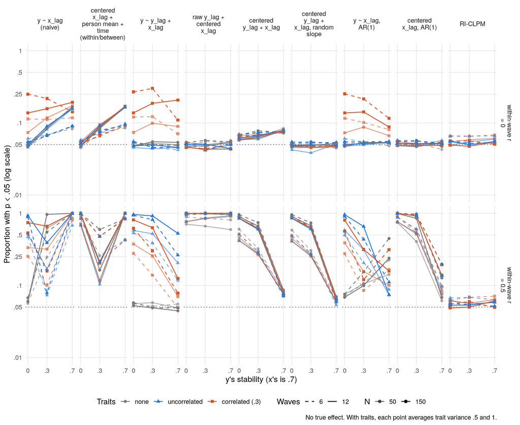

```r
ggplot(d_lag, aes(x = sy, y = pmax(reject_rate, fp_floor), color = trait, shape = trait, alpha = N, linetype = Waves,
                  group = interaction(trait, N, Waves))) +
  geom_hline(yintercept = .05, color = 'gray30', linetype = 'dotted') +
  geom_line(linewidth = .6) + geom_point(size = 1.8) +
  scale_alpha_manual(values = c('50' = .6, '150' = 1), name = 'N') +
  scale_linetype_manual(values = c('6' = 'dashed', '12' = 'solid'), name = 'Waves') +
  facet_grid(co ~ model, labeller = label_wrap_gen(14)) +
  scale_y_log10(limits = c(fp_floor, 1), breaks = c(.01, .05, .1, .25, .5, 1), labels = c('.01', '.05', '.1', '.25', '.5', '1')) +
  scale_x_continuous(breaks = c(0, .3, .7), labels = c('0', '.3', '.7'), name = "y's stability (x's is .7)") +
  scale_color_manual(values = c(none = '#7a7a7a', uncorrelated = '#2a78d6', 'correlated (.3)' = '#d4572a'), name = 'Traits') +
  scale_shape_manual(values = c(none = 16, uncorrelated = 17, 'correlated (.3)' = 15), name = 'Traits') +
  labs(y = 'Proportion with p < .05 (log scale)',
       caption = 'No true effect. With traits, each point averages trait variance .5 and 1.') +
  sim_theme() + theme(axis.text.x = element_text(angle = 0, hjust = .5))
```

```r
# Claims made in the text below.
both_stable <- function(d) d$sy == .7 & d$co == 0 & d$v == 0
check_claim(fac_mean('mean_est', c('naive', 'sea'), 'lag', is_('clxy', 0), both_stable) < .005 &&
              fac_mean('reject_rate', c('naive', 'sea'), 'lag', is_('clxy', 0), both_stable) > .1 &&
              fac_mean('reject_rate', c('no_wcen_ar', 'no_wcen_ylag'), 'lag', is_('clxy', 0), both_stable) < .06,
            'with both series stable and nothing else connecting them, naive and within/between are unbiased but reject > .1, and AR(1) and lagged y are near .05')
check_claim(fac_mean('reject_rate', 'naive', 'lag', is_('clxy', 0), is_('sy', 0), is_('co', .5), is_('v', 0)) < .08 &&
              fac_mean('reject_rate', 'sea', 'lag', is_('clxy', 0), is_('sy', 0), is_('co', .5), is_('v', 0)) > .5 &&
              fac_mean('mean_est', 'sea', 'lag', is_('clxy', 0), is_('sy', 0), is_('co', .5), is_('v', 0)) < -.1,
            'with no y stability, the naive model is close to .05 but the within/between model is biased negative and rejects most of the time')
pair <- function(spec, tc) fac_mean('reject_rate', spec, 'lag', is_('clxy', 0), is_('co', 0), function(d) d$v > 0, is_('tcor', tc))
check_claim(all(sapply(c('naive', 'no_wcen_ylag', 'no_wcen_ar'), function(s) pair(s, .3) > pair(s, 0) + .04)) &&
              all(sapply(c('sea', 'wcen_x_raw_ylag', 'wcen_ylag', 'wcen_ylag_wcenre', 'wcen_ar', 'riclpm'), function(s) abs(pair(s, .3) - pair(s, 0)) < .01)),
            'a trait correlation raises the rate only for the models that do not center x')
wcy <- function(stat, s, w) fac_mean(stat, 'wcen_ylag', 'lag', is_('clxy', 0), is_('co', .5), is_('sy', s), is_('waves', w))
check_claim(wcy('mean_est', 0, 6) < -.1 && wcy('mean_est', 0, 12) < -.05 &&
              abs(wcy('mean_est', 0, 12)) < .6 * abs(wcy('mean_est', 0, 6)) &&
              abs(wcy('mean_est', .7, 6)) < .005 && abs(wcy('mean_est', .7, 12)) < .005,
            'centered lagged y is biased negative when y is less stable than x, the bias about halving from 6 to 12 waves, and unbiased at equal stabilities')
bs <- function(stat, w) fac_mean(stat, c('naive', 'sea'), 'lag', is_('clxy', 0), both_stable, is_('waves', w))
check_claim(bs('reject_rate', 12) > bs('reject_rate', 6) && bs('sd_over_se', 6) > 1.05 &&
              max(fac_cells(c('no_wcen_ar', 'no_wcen_ylag'), 'lag', is_('clxy', 0), both_stable)$reject_rate) < .06,
            'both stable: naive and within/between error rates are more inflated with 12 waves than 6, SEs too small; uncentered lagged y and AR(1) every cell below .06')
check_claim(fac_mean('mean_est', 'naive', 'lag', is_('clxy', 0), is_('sy', 0), is_('co', .5), function(d) d$v > 0) < -.05 &&
              fac_mean('reject_rate', 'naive', 'lag', is_('clxy', 0), is_('sy', 0), is_('co', .5), function(d) d$v > 0) > .3 &&
              all(fac_cells('sea', 'lag', is_('clxy', 0), is_('sy', 0), is_('co', .5), is_('v', 0))$mean_est < -.05),
            'with no y stability, the naive model is biased once there are traits, and the within/between model is biased without them')
check_claim(max(abs(fac_cells('wcen_ylag', 'lag', is_('clxy', 0), is_('co', 0))$mean_est)) < .01,
            'centered x with centered lagged y is unbiased whenever there is no within-wave correlation')
tc_diff <- function(spec, co) {
  a <- fac_cells(spec, 'lag', is_('clxy', 0), is_('co', co), function(d) d$v > 0)
  key <- paste(a$n, a$waves, a$sy, a$v)
  r3 <- a$reject_rate[a$tcor == .3][order(key[a$tcor == .3])]
  r0 <- a$reject_rate[a$tcor == 0][order(key[a$tcor == 0])]
  r3 - r0
}
check_claim(all(sapply(c('sea', 'wcen_x_raw_ylag', 'wcen_ylag', 'wcen_ylag_wcenre', 'wcen_ar', 'riclpm'), function(s) max(abs(tc_diff(s, .5))) < .04)) &&
              any(tc_diff('no_wcen_ylag', .5) < -.1) && any(tc_diff('no_wcen_ar', .5) > .1) && any(tc_diff('no_wcen_ar', .5) < -.1),
            'with a within-wave correlation, the trait correlation leaves centered models and the RI-CLPM alone (within .04) but moves uncentered models both ways')
fac_old <- fac[fac$sy == .7 & fac$co == .5 & fac$waves == 12 & fac$clxy == 0 & fac$tcor == 0 & fac$n == 150 & fac$role == 'lag', ]
old_name <- c(naive = 'naive', sea = 'sea', no_wcen_ylag = 'no_wcen_ylag', wcen_x_raw_ylag = 'wcen_x_raw_ylag',
              wcen_ylag = 'wcen_ylag_l4', wcen_ylag_wcenre = 'wcen_ylag_l4_wcenre', no_wcen_ar = 'no_wcen_ar',
              wcen_ar = 'wcen_ar', riclpm = 'riclpm')
# Rates of exactly 1 in both runs have an SE of 0 (z is NaN); those are
# compared directly. Estimates are compared too.
repro <- do.call(rbind, mapply(function(s, v, r, se, est, sd, nv){
  o <- cells(old_name[[s]], v, 150)
  data.frame(z_rate = (r - o$fp_rate) / sqrt(se^2 + o$mc_se^2), both_one = r == 1 && o$fp_rate == 1,
             z_est = (est - o$mean_est) / sqrt(sd^2 / nv + o$sd_est^2 / o$n_valid))
}, fac_old$spec, fac_old$v, fac_old$reject_rate, fac_old$mc_se, fac_old$mean_est, fac_old$sd_est, fac_old$n_valid, SIMPLIFY = FALSE))
check_claim(nrow(fac_old) == 26 && all(ifelse(repro$both_one, TRUE, abs(repro$z_rate) < 3)) && all(abs(repro$z_est) < 3.5),
            'at the original settings and N = 150, the factorial reproduces the 10,000-replication rates and estimates within Monte Carlo error')
```

The first thing the factorial shows is that the “safe cases” above are only half safe. With y as stable as x and nothing else connecting them (no within-wave correlation, no traits), the naive and within/between models aren’t biased (average estimates within .002 of zero), but they still reject .088 of the time with 6 waves and .164 with 12. The estimates vary 1.16 and 1.41 times as much as the standard errors say, probably because the residuals of a model without $y_{t-1}$ are autocorrelated and the standard errors assume they aren’t (the old problem of relating two autocorrelated series, Bartlett 1935; Granger and Newbold 1974). Uncentered lagged y and AR(1) residuals are fine there. The other safe case, a y with no stability, holds for the naive model only when people don’t differ in their usual levels (.061 with no traits); with traits its average estimate is -.082 and it rejects .585 of the time. The within/between model is biased even without traits: average estimates of -.235 with 6 waves and -.101 with 12.

That negative bias seems to come from centering on the observed person mean (a random-intercept model partly centers x too, which may be why the naive model picks it up once there are traits), and it also shows up in centered x with centered lagged y once y is less stable than x and the two are correlated within a wave. With no y stability, its average estimate is -.163 with 6 waves and -.077 with 12, and the rate is .727 and .645. It’s unbiased when y is as stable as x (the only case the earlier simulations looked at) and whenever there’s no within-wave correlation. It looks like a cousin of the bias Nickell (1981) described for a lagged outcome with fixed effects, which is negative, shrinks roughly as one over the number of waves, and also shows up in person-mean-centered multilevel models (Hamaker and Grasman 2015; Falkenström et al. 2017). Fixed-effects estimates are known to be biased whenever a predictor isn’t strictly exogenous (Allison et al. 2017), and here lagged x isn’t, because x moves with y within a wave. My guess at the mechanism: the person mean includes this month’s x, which moves with this month’s y, so subtracting it pulls the lagged coefficient down by something like one over the number of waves. That fits the bias about halving from 6 to 12 waves (see the figure below). I don’t know why it cancels when the stabilities are equal, and y was never more stable than x here.

Without a within-wave correlation, a trait correlation hurts only the models that don’t center x: going from uncorrelated to correlated traits takes the rate for lagged y from .047 to .149, AR(1) from .053 to .123, and the naive model from .084 to .150, and the centered models and the RI-CLPM stay where they were. With a within-wave correlation, it still leaves the centered models and the RI-CLPM alone, but it pushes the uncentered models’ rates around in both directions, sometimes down, by offsetting their other biases.

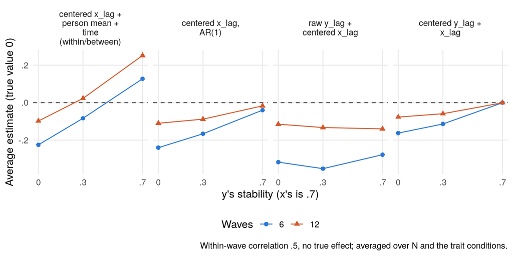

```r
d_bias <- fac[fac$role == 'lag' & fac$clxy == 0 & fac$co == .5 & fac$spec %in% c('sea', 'wcen_ylag', 'wcen_x_raw_ylag', 'wcen_ar'), ]
d_bias <- aggregate(mean_est ~ spec + sy + waves, data = d_bias, FUN = mean)
d_bias$model <- factor(fac_labels[d_bias$spec], levels = fac_labels[c('sea', 'wcen_ar', 'wcen_x_raw_ylag', 'wcen_ylag')])
d_bias$waves <- factor(d_bias$waves)
ggplot(d_bias, aes(x = sy, y = mean_est, color = waves, shape = waves)) +
  geom_hline(yintercept = 0, color = 'gray30', linetype = 'dashed') +
  geom_line(linewidth = .5) + geom_point(size = 2) +
  facet_wrap(~ model, nrow = 1, labeller = label_wrap_gen(18)) +
  scale_x_continuous(breaks = c(0, .3, .7), labels = c('0', '.3', '.7'), name = "y's stability (x's is .7)") +
  scale_color_manual(values = c('6' = '#2a78d6', '12' = '#d4572a'), name = 'Waves') +
  scale_shape_manual(values = c('6' = 16, '12' = 17), name = 'Waves') +
  scale_y_continuous(labels = function(x) f3(x, 1)) +
  labs(y = 'Average estimate (true value 0)',
       caption = 'Within-wave correlation .5, no true effect; averaged over N and the trait conditions.') +
  sim_theme() + theme(axis.text.x = element_text(angle = 0, hjust = .5))
```

## The concurrent model

```r
conc_specs <- c('sea_concurrent', 'sea_concurrent_ylag', 'sea_concurrent_wcen_ylag')
cw <- function(stat, spec, ...) fac_mean(stat, spec, 'within', function(d) d$null, ...)
check_claim(max(abs(fac_cells(conc_specs, 'within', function(d) d$null)$mean_est)) < .01 &&
              cw('reject_rate', 'sea_concurrent', is_('sy', .7)) > .1 && cw('reject_rate', 'sea_concurrent', is_('sy', 0)) < .06 &&
              cw('reject_rate', 'sea_concurrent', is_('sy', .7), is_('waves', 12)) > cw('reject_rate', 'sea_concurrent', is_('sy', .7), is_('waves', 6)),
            'the concurrent within-person term is unbiased but its error rate is inflated as y stability rises, more so with more waves')
check_claim(abs(cw('reject_rate', 'sea_concurrent_ylag') - .05) < .01 &&
              cw('reject_rate', 'sea_concurrent_wcen_ylag', is_('sy', .7)) < cw('reject_rate', 'sea_concurrent', is_('sy', .7)) &&
              cw('reject_rate', 'sea_concurrent_wcen_ylag', is_('sy', 0)) > cw('reject_rate', 'sea_concurrent', is_('sy', 0)) &&
              min(fac_cells('sea_concurrent_wcen_ylag', 'within', function(d) d$null)$reject_rate) > .05,
            'raw lagged y fixes the concurrent term; centered lagged y helps at high y stability but leaves the error rate inflated everywhere, worse than the bare model at sy = 0')
check_claim(abs(cw('reject_rate', 'sea_concurrent', is_('tcor', .3), function(d) d$v > 0) -
                  cw('reject_rate', 'sea_concurrent', is_('tcor', 0), function(d) d$v > 0)) < .01 &&
              fac_mean('reject_rate', 'sea_concurrent', 'between', is_('co', 0), is_('clxy', 0), is_('tcor', .3), function(d) d$v > 0) > .2,
            'the trait correlation shows up in the between-person term, not the within-person one')
# RI-CLPM rejection rate under the .1 effect, for the next section.
rp <- function(n, w) fac_mean('reject_rate', 'riclpm', 'lag', is_('clxy', .1), is_('n', n), is_('waves', w))
# Person-mean (between) term with no within-wave correlation and no cross-lag,
# by trait correlation; its true value is 0 only when tcor = 0.
cb <- function(spec, tc) fac_mean('reject_rate', spec, 'between', is_('co', 0), is_('clxy', 0), function(d) d$v > 0, is_('tcor', tc))
check_claim(all(sapply(conc_specs, function(s) cb(s, .3) > .2)) && cb('sea_concurrent_ylag', .3) < cb('sea_concurrent', .3) - .03 &&
              max(abs(fac_cells(conc_specs, 'between', function(d) d$null)$reject_rate - .05)) < .025 &&
              all(abs(sapply(c(0, .3, .7), function(y) cw('reject_rate', 'sea_concurrent', is_('sy', y), is_('tcor', .3), function(d) d$v > 0) -
                                                     cw('reject_rate', 'sea_concurrent', is_('sy', y), is_('tcor', 0), function(d) d$v > 0))) < .02),
            'the person-mean term picks up the trait correlation (less so with raw lagged y), holds its error rate otherwise, and the within-person term is unaffected by it at every y stability')
# Both terms, no within-wave correlation and no cross-lag, every trait condition.
d_conc <- fac[fac$spec %in% conc_specs & fac$co == 0 & fac$clxy == 0, ]
d_conc <- aggregate(reject_rate ~ spec + role + sy + trait + n + waves, data = d_conc, FUN = mean)
d_conc$model <- factor(fac_labels[d_conc$spec], levels = fac_labels[conc_specs])
d_conc$term <- factor(ifelse(d_conc$role == 'within', 'within-person x\n(true value 0)', 'person mean of x\n(not 0 when traits correlate)'),
                      levels = c('within-person x\n(true value 0)', 'person mean of x\n(not 0 when traits correlate)'))
d_conc$trait <- factor(d_conc$trait, levels = c('none', 'uncorrelated', 'correlated (.3)'))
d_conc$N <- factor(d_conc$n, levels = c(50, 150))
d_conc$Waves <- factor(d_conc$waves, levels = c(6, 12))
```

The within/between model is often used concurrently, too: this month’s y on this month’s centered x, the person mean of x, and time. In Sanjay Srivastava’s lab we’d have added last month’s y, to ask whether x goes with y over and above where y already was. Under the null for the concurrent within-person term (no within-wave correlation and no cross-lag), the estimate is unbiased, but the error rate is inflated as y gets more stable, probably for the same reason as above: x and y are each autocorrelated, so the model sees more independent information than there is. Adding raw lagged y fixes it. Centered lagged y helps when y is quite stable but leaves the error rate somewhat inflated everywhere, even where the bare model was fine (see the figure). The trait correlation shows up where it should, in the person-mean term (which finds it .396 of the time, averaged over N and waves), and doesn’t leak into the within-person one at any level of y’s stability, including none (.050 with correlated traits and no y stability). Adding raw lagged y takes some of that between-person association with it (.326), probably because last month’s raw y carries each person’s usual level; the person-mean terms hold their error rate when the traits are uncorrelated.

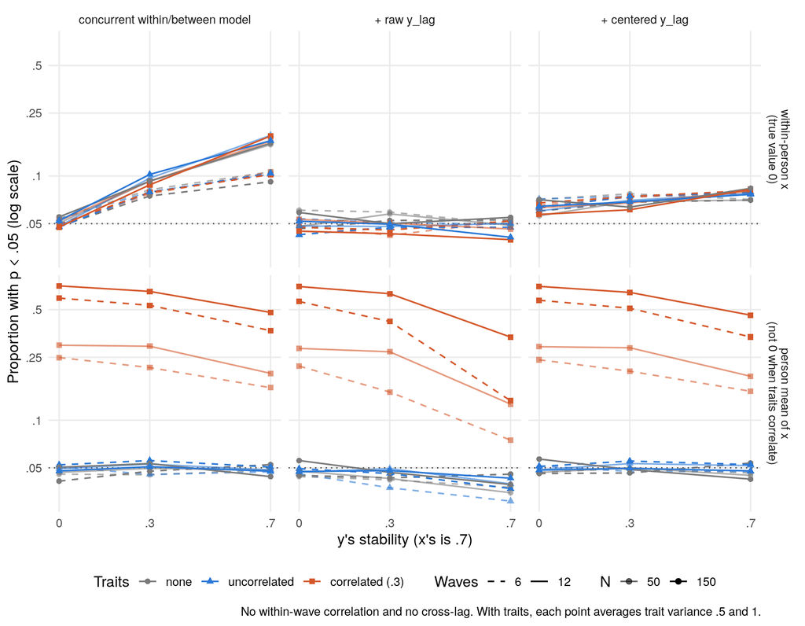

```r
ggplot(d_conc, aes(x = sy, y = reject_rate, color = trait, shape = trait, alpha = N, linetype = Waves,
                   group = interaction(trait, N, Waves))) +
  geom_hline(yintercept = .05, color = 'gray30', linetype = 'dotted') +
  geom_line(linewidth = .6) + geom_point(size = 1.8) +
  facet_grid(term ~ model) +
  scale_y_log10(breaks = c(.025, .05, .1, .25, .5, 1), labels = c('.025', '.05', '.1', '.25', '.5', '1'),
                name = 'Proportion with p < .05 (log scale)') +
  scale_x_continuous(breaks = c(0, .3, .7), labels = c('0', '.3', '.7'), name = "y's stability (x's is .7)") +
  scale_color_manual(values = c(none = '#7a7a7a', uncorrelated = '#2a78d6', 'correlated (.3)' = '#d4572a'), name = 'Traits') +
  scale_shape_manual(values = c(none = 16, uncorrelated = 17, 'correlated (.3)' = 15), name = 'Traits') +
  scale_alpha_manual(values = c('50' = .6, '150' = 1), name = 'N') +
  scale_linetype_manual(values = c('6' = 'dashed', '12' = 'solid'), name = 'Waves') +
  labs(caption = 'No within-wave correlation and no cross-lag. With traits, each point averages trait variance .5 and 1.') +
  sim_theme() + theme(axis.text.x = element_text(angle = 0, hjust = .5))
```

## With a true effect

With a lagged effect of .1, power is only meaningful for models that hold their error rate. The RI-CLPM comes closest: its null rates are .041 to .074, slightly inflated at N = 50 with 6 waves, which is also where most of its fit warnings are (and it’s the generating model here, so this is its best case). It recovers the effect (average estimate .099), and the number of waves matters more for finding it than N does: .264 at N = 50 with 6 waves, .634 with 12, and .598 and .974 at N = 150. The other models’ rates under the alternative mix the effect with their biases, so I haven’t summarized them here; they’re in `summary_cells.csv`.

```r
ric_null <- fac_cells('riclpm', 'lag', is_('clxy', 0))
hot_cell <- function(d) d$n == 50 & d$waves == 6
check_claim(abs(fac_mean('mean_est', 'riclpm', 'lag', is_('clxy', .1)) - .1) < .005 &&
              max(ric_null$reject_rate) < .08 &&
              mean(ric_null$reject_rate[hot_cell(ric_null)]) == max(tapply(ric_null$reject_rate, paste(ric_null$n, ric_null$waves), mean)) &&
              mean(ric_null$warn_rate[hot_cell(ric_null)]) == max(tapply(ric_null$warn_rate, paste(ric_null$n, ric_null$waves), mean)) &&
              rp(50, 12) - rp(50, 6) > rp(150, 6) - rp(50, 6),
            'the RI-CLPM recovers .1; its null rates are below .08, most inflated at N = 50 / 6 waves where warnings are most common; waves matter more than N for power')
```

# Limits

The factorial only runs N = 50 and 150, with x’s stability fixed at .7 and y’s never above it, one nonzero level each of the within-wave correlation, the trait correlation and the true effect, no effect of y on x, equal trait variances for x and y, and complete, balanced, normal data. The RI-CLPM is also the model that generates the data with traits, and it isn’t fit to the data without them. N = 600 and 24 waves (most of the computing cost) are the obvious next additions; they’d say whether the centering bias keeps shrinking with more waves and whether the biases that grow with N show up the same way here.

# References

Allison, Paul D., Richard Williams, and Enrique Moral-Benito. 2017. “Maximum Likelihood for Cross-Lagged Panel Models with Fixed Effects.” *Socius: Sociological Research for a Dynamic World* 3 (January). https://doi.org/10.1177/2378023117710578.

Asparouhov, Tihomir, Ellen L. Hamaker, and Bengt Muthén. 2018. “Dynamic Structural Equation Models.” *Structural Equation Modeling: A Multidisciplinary Journal* 25 (3): 359–88. https://doi.org/10.1080/10705511.2017.1406803.

Bartlett, M. S. 1935. “Some Aspects of the Time-Correlation Problem in Regard to Tests of Significance.” *Journal of the Royal Statistical Society* 98 (3): 536. https://doi.org/10.2307/2342284.

Curran, Patrick J., and Daniel J. Bauer. 2011. “The Disaggregation of Within-Person and Between-Person Effects in Longitudinal Models of Change.” *Annual Review of Psychology* 62 (1): 583–619. https://doi.org/10.1146/annurev.psych.093008.100356.

Falkenström, Fredrik, Steven Finkel, Rolf Sandell, Julian A. Rubel, and Rolf Holmqvist. 2017. “Dynamic Models of Individual Change in Psychotherapy Process Research.” *Journal of Consulting and Clinical Psychology* 85 (6): 537–49. https://doi.org/10.1037/ccp0000203.

Granger, C. W. J., and P. Newbold. 1974. “Spurious Regressions in Econometrics.” *Journal of Econometrics* 2 (2): 111–20. https://doi.org/10.1016/0304-4076(74)90034-7.

Hamaker, Ellen L., and Raoul P. P. P. Grasman. 2015. “To Center or Not to Center? Investigating Inertia with a Multilevel Autoregressive Model.” *Frontiers in Psychology* 5 (January). https://doi.org/10.3389/fpsyg.2014.01492.

Hamaker, Ellen L., Rebecca M. Kuiper, and Raoul P. P. P. Grasman. 2015. “A Critique of the Cross-Lagged Panel Model.” *Psychological Methods* 20 (1): 102–16. https://doi.org/10.1037/a0038889.

Lüdtke, Oliver, Herbert W. Marsh, Alexander Robitzsch, Ulrich Trautwein, Tihomir Asparouhov, and Bengt Muthén. 2008. “The Multilevel Latent Covariate Model: A New, More Reliable Approach to Group-Level Effects in Contextual Studies.” *Psychological Methods* 13 (3): 203–29. https://doi.org/10.1037/a0012869.

Nickell, Stephen. 1981. “Biases in Dynamic Models with Fixed Effects.” *Econometrica* 49 (6): 1417. https://doi.org/10.2307/1911408.

Wang, Lijuan (Peggy), and Scott E. Maxwell. 2015. “On Disaggregating Between-Person and Within-Person Effects with Longitudinal Data Using Multilevel Models.” *Psychological Methods* 20 (1): 63–83. https://doi.org/10.1037/met0000030.